# Take 1: A story of david and goliath

Our first attempt can be read about and accessed in the notebook Project_attempt_1.ipynb

# Take 2: Gathering and analyzing better data

[figure not shown]

About halfway into our project, we realized that our data was less than ideal for a few reasons. First, our Box Office Mojo data originally only scraped the top 100 ranked movies for each year. This represented only the upper eschelon of movie incomes. The low range of incomes, we presume, had less power to pick up a trend or correlation with valence statistics. We realized that Box Office Mojo actually includes a lot more movies! Rather than just the top 100, Box Office Mojo actually provides grossing information on all of the major movies for the year at hand, which is usally above 500. Second, the overlap between our IMDB data set from Stanford and our Box Office Mojo was just over 300 movies representing 4,111 overlapping reviews. We decided that we needed more data to better determine predictive power and the presence of trends. Third, our IMDB data represented only polarized reviews, i.e. those with stars below 4 or above 7. We decided that this would decrease ability to test one particuar hypothesis: that polarizing movies earn more money. As a result, we needed to scrape a balanced sample of reviews from IMDB for each movie, not discriminating based on number of stars. We want reviews in in the 4-7 star range.

Our new approach, as charted below, was to scrape *all* data from Box Office Mojo from 1990-2015, resulting in about 11,000 movies. For each of those movies, we scraped a max of 100 reviews from IMDB's website. This resulted in a final data set containing over half a million reviews, which were no longer only polarized. We feel that the new data is more fit to truly convey the presence or absence of trends and predictive power of gross income on review sentiment.

```python
%matplotlib inline
import numpy as np
import scipy as sp
import matplotlib as mpl
import matplotlib.cm as cm
import matplotlib.pyplot as plt
import pandas as pd
import time
import json
import statsmodels.api as sm
from statsmodels.formula.api import logit, glm, ols
from random import random
pd.set_option('display.width', 500)
pd.set_option('display.max_columns', 100)
pd.set_option('display.notebook_repr_html', True)
import seaborn as sns
sns.set_style("whitegrid")
sns.set_context("poster")
import math
from sklearn.svm import LinearSVC
```

## Scraping and cleaning the data

As mentioned above, we now scrape *all* data from Box Office Mojo from 1990-2015, resulting in about 11,000 movies. For each of those movies, we scraped a max of 100 reviews from IMDB's website. This resulted in a final data set containing over half a million reviews, which were no longer only polarized. We feel that the new data is more fit to truly convey the presence or absence of trends and predictive power of gross income on review sentiment.

### Scraping BOM for box office data

```python
from bs4 import BeautifulSoup
import requests
```

Let's create a data frame `bom_df` to contain the scraped Box Office Mojo data.

```python
bom_df = pd.DataFrame(columns=['close_date', 'gross', 'open_date', 'opening_gross', 'opening_theaters','ranking','title','total_theaters','year'])
```

The function `rowInfoGrabber` retrieves relevant values from each row in a Box Office Mojo table.

```python
def rowInfoGrabber(r):
    info = []
    # Ranking
    info.append(int(r.find("font").get_text()))
    # Title
    info.append(r.find("a").get_text())
    # Gross
    info.append(int(r.find("td", attrs={"align":"right"}).find("b").get_text().strip("$").replace(",","")))
    '''
    For the next 3 categories, we need to deal with the 2000 Anomaly "Fantasia" where there are missing numbers.
    In this case I have chosen to replace the missing values 'N/A' with the values from 'Final Destination', which
    if right above it in the movie table and differs in gross income by about $1 million, which is a small
    difference. See the picture below for a snapshot of the anomaly in the movie table from 2000.
    '''
    # Total number of theaters
    if r.find_all("td",attrs={"align":"right"})[1].find("font").get_text().replace(",","") == 'N/A':
        info.append(2587)
    else:
        info.append(int(r.find_all("td",attrs={"align":"right"})[1].find("font").get_text().replace(",","")))
    # Opening Gross
    if r.find_all("td", attrs={"align":"right"})[2].find("font").get_text().strip("$").replace(",","") == 'N/A':
        info.append(10015822)
    else:
        info.append(int(r.find_all("td", attrs={"align":"right"})[2].find("font").get_text().strip("$").replace(",","")))
    # Opening Number of Theaters
    if r.find_all("td", attrs={"align":"right"})[3].find("font").get_text().replace(",","") == 'N/A':
        info.append(2587)
    else:
        info.append(int(r.find_all("td", attrs={"align":"right"})[3].find("font").get_text().replace(",","")))
    # Date of Opening
    if not r.find_all("td", attrs={"align":"right"})[4].find("a"):
        info.append("-")
    else:
        info.append(r.find_all("td", attrs={"align":"right"})[4].find("a").get_text())
    # Date of Closing: Before 2002 they didn't have a "closing" date in their tables. We must account for this.
    if (len(r.find_all("td", attrs={"align":"right"})) <= 5):
        info.append('-')
    else:
        info.append(r.find_all("td", attrs={"align":"right"})[5].find("font").get_text())
    return info
```

Let's scrape all movies from Box Office Mojo from 1990-2015. This takes about 4 minutes.

```python
%%time
fields = ["ranking", "title", "gross", "total_theaters", "opening_gross", "opening_theaters", "open_date", "close_date"]
years = [1990 + i for i in range(26)]
for year in years:
    print year
    pageText = requests.get("http://www.boxofficemojo.com/yearly/chart/?yr=%(yr)d&p=.htm" % {'yr':year})
    soup = BeautifulSoup(pageText.text, "html.parser")
    movieTable = soup.find("td", attrs={"colspan":"3"})
    movieRows = movieTable.find("table").find_all("tr")[2:102]
    movie_dicts = [dict(zip(fields, rowInfoGrabber(row))) for row in movieRows]
    year_df = pd.DataFrame(movie_dicts)
    year_df['year'] = year
    bom_df = bom_df.append(year_df, ignore_index=True)
    # See how many pages of movies there are for this particular year
    extraPageLinks = soup.find("center").find("font", attrs={"face":"Verdana"}).find("b").find_all("a")
    time.sleep(1)
    for p in extraPageLinks:
        pageText = requests.get('http://www.boxofficemojo.com' + p['href'])
        soup = BeautifulSoup(pageText.text, "html.parser")
        movieTable = soup.find("td", attrs={"colspan":"3"})
        movieRows = movieTable.find("table").find_all("tr")
        movieRows = movieRows[2:len(movieRows)-4]
        movie_dicts = [dict(zip(fields, rowInfoGrabber(row))) for row in movieRows]
        year_df = pd.DataFrame(movie_dicts)
        year_df['year'] = year
        bom_df = bom_df.append(year_df, ignore_index=True)
        time.sleep(1)
```

```
1990
1991
1992
1993
1994
1995
1996
1997
1998
1999
2000
2001
2002
2003
2004
2005
2006
2007
2008
2009
2010
2011
2012
2013
2014
2015
CPU times: user 58.8 s, sys: 893 ms, total: 59.7 s
Wall time: 3min 57s
```

Let's see how it looks.

```python
bom_df.head()
```

|  | close_date | gross | open_date | opening_gross | opening_theaters | ranking | title | total_theaters | year |
| --- | --- | --- | --- | --- | --- | --- | --- | --- | --- |
| 0 | - | 285761243 | 11/16 | 17081997 | 1202 | 1 | Home Alone | 2173 | 1990 |
| 1 | - | 217631306 | 7/13 | 12191540 | 1101 | 2 | Ghost | 1766 | 1990 |
| 2 | - | 184208848 | 11/9 | 598257 | 14 | 3 | Dances with Wolves | 1636 | 1990 |
| 3 | - | 178406268 | 3/23 | 11280591 | 1325 | 4 | Pretty Woman | 1811 | 1990 |
| 4 | - | 135265915 | 3/30 | 25398367 | 2006 | 5 | Teenage Mutant Ninja Turtles | 2377 | 1990 |

Now we'll save and reload so we don't have to do that again.

```python
with open('newBOM.json','r') as fp:
    bom_dict = json.load(fp)
bom_df = pd.DataFrame(bom_dict)
```

### Scraping IMDB for reviews

We want a less polarized review set in order to more accurately determine the effect of review polarity on gross income. For this we'll have to part with Andrew Maas's Large Movie Review Data Set and scrape IMDB ourselves for a mixture of polarized and non-polarized reviews for each movie. Unfortunately, IMDB's URLs contain a movie ID rather than a movie title, so we cannot request each page's HTML using the mere title. Fortunately, the IMDB API allows us to obtain a movie's IMDB ID based on its title by returning a JSON object.

Let's create a helper function that returns the relevant url used to query the OMDB API given the movie's title.  
An example url is http://www.omdbapi.com/?t=Jurassic%20World.

```python
'''
Name: urlOMDB
Input: Movie name
Output: url used to Query OMDB API
'''
def urlOMDB(title):
    base = "http://www.omdbapi.com/?t="
    base += title.split()[0]
    for word in title.split()[1:]:
        base += "%20" + word
    return base
```

Let's test our function by getting the IMDB ID for "Jurassic World".

```python
requests.get(urlOMDB("Jurassic World")).json()['imdbID']
```

```
u'tt0369610'
```

Perfect. Now we'll use these IDs to scrape IMDB for each movie in our Box Office Mojo page. First, let's write a function `reviewsGrabber` which returns a list of (title of review, stars, text of review) tuples for a given IMDB *webpage*. The function cleans the review texts upon collecting them by removing punctuation and converting to lower case.

```python
'''
Name: reviewsGrabber
Input: url (webpage)
Output: [(titleOfReview1, stars1, review1), (titleOfReview2, stars2, review2), ... (titleofReviewn, starsn, reviewn)]
'''
punctuation = set('.,;:!?()[]{}`''\"@#$%^&*+-|-=~_')

def reviewsGrabber(url):
    pageText = requests.get(url)
    soup = BeautifulSoup(pageText.text, "html.parser")
    reviewTable = soup.find("div", attrs={"id":"tn15content"})
    divs = []
    for rev in reviewTable.find_all("div", attrs={"class": None}):
        if len(rev.find_all("img")) > 1:
            divs.append((rev.find("h2").get_text(), int(rev.find_all("img")[1]['alt'].split("/")[0])))
        else:
            divs.append((rev.find("h2").get_text(), 'N/A'))
    reviews = []
    for rev in reviewTable.find_all("p")[:len(reviewTable.find_all("p"))-1]:
        if len(rev.find_all("b")) == 0:
            text = rev.get_text()
            text = ''.join(ch for ch in text if ch not in punctuation).replace("\n", " ").lower()
            reviews.append(text)
    return [(title,stars,text) for ((title,stars), text) in zip(divs,reviews)]
```

Now let's scrape each web page based on the movies in `bom_df`. We'll take a max of 100 movies reviews for each movie. Some movies have less than 100 reviews. IMDB lists reviews by default from best to worst. We don't want that. Fortunately, they offer the option to sort in chronological order, this works particularly well for our project, because we want to see whether the earliest reviews are a good indicator for box office performance over the opening weekend.

#### The following code took about 24 hours to run on my computer. Do not run it again.

I would frequenty see an error, account for it by tweaking the code (maybe throw in a try catch here and there), then continue where the code left off by changing the variable "count". (You can see that the most recent stopping point was 11,011.) Every once in awhile, the code spits out my progress as a percentage. Babysitting my computer was quite the experience.

```python
# fields = ['title','text','stars','close_date','open_date','opening_gross','gross','rank','total_theaters','year']
# count = 11011
# for index, row in bom_df[count:].iterrows():
#     close, gross, op, op_gross, open_th, r, title, thea, yr = tuple([row[i] for i in range(9)])
#     if random() < 0.02:
#         print str(count*100.0 / 11858) + "%"
#     try:
#         omdb = requests.get(urlOMDB(title)).json()
#     except ValueError:
#         continue

#     omdbJSON = dict(omdb)
#     if 'Error' in omdbJSON.keys():
#         continue
#     else:
#         imdbID = str(omdb['imdbID'])
#     time.sleep(0.1)
#     reviews = []
#     baseURL = 'http://www.imdb.com/title/%(imdbID)s/reviews?filter=chrono' % {'imdbID':imdbID}
#     pageText = requests.get(baseURL)
#     soup = BeautifulSoup(pageText.text, "html.parser")
#     if soup.find("div", attrs={'class':'error_code_404'}):
#         continue
#     try:
#         reviews = reviews + reviewsGrabber(baseURL)
#     except AttributeError:
#         continue
#     # Let's scrape the number of reviews for this given movie.
#     table = soup.find("div", attrs={"id":"tn15content"}).find_all("table", attrs={'border':'0'})
#     if table == []:
#         continue
#     td = table[1].find("td", attrs = {'align':'right'})
#     if td == None:
#         continue
#     else:
#         text = td.get_text()
#     n_reviews = int(text.split("reviews")[0].split("\n")[1])
#     # This number represents the page: page p is represented in the url as the integer 10(p-1)
#     p = 10
#     while len(reviews) < min(n_reviews, 100):
#         url = baseURL + ";filter=chrono" + str(";start=%(page)d" % {'page': p})
#         reviews = list(reviews + reviewsGrabber(url))
#         p += 10

#     reviews = reviews[:100]
# #     review_dict = [dict(zip(fields, [[] for i in range(len(fields))]))]
#     for review in reviews:
#         review_dict = {'title':[title], 'text': [review[2]], 'review_title': [review[0]], 'stars': [review[1]],
#                        'close_date': [close],'gross': [gross], 'open_date': [op], 'opening_gross':[op_gross],
#                        'opening_theaters': [open_th], 'rank':[r], 'theaters': [thea], 'year': [yr]}

#         combined_df = combined_df.append(pd.DataFrame(review_dict), ignore_index=True)
#     count += 1
```

Let's save our finally scraped movie reviews.

```python
# fp = open("complete.json","w")
# json.dump(combined_df.to_dict(), fp)
# fp.close()

with open("complete.json", "r") as fd:
    combined_dict = json.load(fd)
combined_df = pd.DataFrame(combined_dict)
```

```python
print "Length of dataframe: ", len(combined_df.gross.values)
```

Because some films do not have a close date, we will have to be careful with the close date! Next, we combine the `close_date`, `open_date` and `year` columns into two columns `close_date` and `open_date` that are time series. This will make it easier for us to work with the data in the future.

```python
def lam(x, month=False):
    if x == '-' or x =='':
        return '1'
    try:
        dummy = int(x)
    except ValueError:
        return '1'
    else:
        return x[:x.find('/')]

# splitting the close_date and open_date into the respective month and day
combined_df['close_month'] = combined_df['close_date'].map(lam)
combined_df['close_day'] = combined_df['close_date'].map(lambda x: '0' if x=='-' else x[x.find('/')+1:len(x)])
combined_df['open_month'] = combined_df['open_date'].map(lam)
combined_df['open_day'] = combined_df['open_date'].map(lambda x: x[x.find('/')+1:len(x)])

# dropping the old close_date and open_date
combined_df = combined_df.drop('close_date', 1)
combined_df = combined_df.drop('open_date', 1)

# creating an open_year by turning the year column into a string and getting rid of trailing bits
combined_df['open_year'] = combined_df.year.astype(str)
combined_df['open_year'] = combined_df.open_year.map(lambda x: x[:x.find('.')])

# creating a close_year column, by looking at whether the close month is earlier/later than the open month in the year
close_month = combined_df.close_month.astype(int)
open_month = combined_df.open_month.astype(int)
year = combined_df['year'].astype(int)
close_year=[]
for i in range (0, len(year)):
    if close_month[i] >= open_month[i]:
        close_year.append(year[i])
    else:
        close_year.append(year[i]+1)
combined_df['close_year'] = close_year
combined_df['close_year'] = combined_df['close_year'].astype(str)
```

```python
# making close_date and open_date by concatenating the year, month and day
import datetime
close_date = []
for index, row in combined_df.iterrows():
    if row.close_day != '0':
        close_date.append(datetime.datetime(int(row.close_year), int(row.close_month), int(row.close_day)))
    else:
        close_date.append(None)
combined_df['close_date'] = close_date
combined_df['open_date']=combined_df.open_year + '-' + combined_df.open_month + '-' + combined_df.open_day
def lam2(x):
    if x[7] == '-' or x[7:10] == 'Jan':
        return x[:7] + "1"
    else:
        return x
combined_df['open_date']=combined_df['open_date'].map(lam2).apply(pd.datetools.parse)
```

Let's drop obselete columns.

```python
combined_df = combined_df.drop('close_day', 1)
combined_df = combined_df.drop('close_month', 1)
combined_df = combined_df.drop('open_day', 1)
combined_df = combined_df.drop('open_month', 1)
```

And now let's save our results again.

```python
# import pymongo
# from bson import json_util

# fp = open("complete_dates.json","w")
# json.dump(combined_df.to_dict(), fp, default=json_util.default)
# fp.close()

with open("complete_dates.json", "r") as fd:
    complete_dates = json.load(fd)
combined_df = pd.DataFrame(complete_dates)
```

Datatime objects are not JSON serializable. We had to make them such, now we need to map them back to normal.

```python
def getdate(dic):
    if dic != None:
        return int(dic["$date"])
    else:
        return None

combined_df.open_date = combined_df.open_date.map(getdate)
combined_df.close_date = combined_df.close_date.map(getdate)
```

### Computing valence statistics by review

It's now time to collect valence statistics on our reviews in order to do sentiment analysis. We'll be using labMT (language assessment by Mechanical Turk), a word score list for sentiment analysis containing over 10,000 words available in the qdap Dictionaries package in R (http://www.inside-r.org/packages/cran/qdapDictionaries/docs/labMT). The file contains a "happiness" value, and ranks words by their happiness. It also includes mean and standard deviation, Twitter rank and Google rank.

```python
url = 'http://www.plosone.org/article/fetchSingleRepresentation.action?uri=info:doi/10.1371/journal.pone.0026752.s001'
labmt = pd.read_csv(url, skiprows=2, sep='\t', index_col=0)
```

```python
labmt.head()
```

Let's make a happiness dictionary consisting of the word's happiness minus the average of all words.

```python
average = labmt.happiness_average.mean()
happiness = (labmt.happiness_average - average).to_dict()
```

Let's look at the happiness values to find a narrow middle range. We'll want to disregard all words in this middle range so they do not overpower the polarized words.

```python
plt.hist(happiness.values())
plt.axvline(np.percentile(happiness.values(),35), color='r')
plt.axvline(np.percentile(happiness.values(),65), color='r')
```

We'll consider words below the 35th and above the 65th percentiles.

```python
lower_bound = np.percentile(happiness.values(),35)
upper_bound = np.percentile(happiness.values(),65)
print lower_bound, upper_bound
```

Now we'll write a function to remove stop words, words that have little to do with sentiment analysis. We use the sklearn package to obtain these words.

```python
from sklearn.feature_extraction import text
stopwords = text.ENGLISH_STOP_WORDS
punctuation = list('.,;:!?()[]{}`''\"@#$%^&*+-|-=~_')

def removeStopWords(text, stopwords = stopwords):
    new_text = ""
    for word in text.split():
        if word not in stopwords:
            while len(word) != 0 and word[-1] in punctuation:
                word = word[:len(word)-1]
            new_text += word + ' '
    return new_text
```

Finally we're ready to analyze a particular review given our valence dictionary. So let's put it in a function.

```python
'''
Name: getValenceInfo()
Inputs: review text, dictionary of happiness
Returns: a 4-tuple of (happiness total, happiness average, total # of scorable words, % of scorable words)
'''
def getValenceInfo(text, valenceDict):
    total_words = len(text.split())
    happiness_total, count_relevant = 0, 0
    for word in text.split():
        try:
            # Only consider words below the 35th and above the 65th percentile
            if valenceDict[word] <= lower_bound or valenceDict[word] >= upper_bound:
                happiness_total += valenceDict[word]
                count_relevant += 1
        except KeyError:
            continue

    if count_relevant != 0:
        avg_valence = 1.*happiness_total/count_relevant
    else:
        avg_valence = 0
    return happiness_total, avg_valence, total_words, 1.*count_relevant / total_words
```

Before we run this through our data frame, let's reset the index.

```python
'''
Name: getAllInfo
Input: data frame, happiness dictionary, list of stop words
Returns: a new data frame with 4 new columns: valence_sum, valence_avg, n_scorables, pct_scorables
'''
def getAllInfo(df, valenceDict, stopwords):
    valence_suml, valence_avgl, review_lenl, review_fractionl = [], [], [], []
    for i, row in df.iterrows():
        if random() < 0.00001:
            print i
        cleaned_review = removeStopWords(row['text'], stopwords)
        valence_sum, valence_avg, review_len, review_fraction = getValenceInfo(cleaned_review, valenceDict)
        valence_suml.append(valence_sum)
        valence_avgl.append(valence_avg)
        review_lenl.append(review_len)
        review_fractionl.append(review_fraction)
    conc = pd.DataFrame({'valence_sum': valence_suml, 'valence_avg':valence_avgl ,'n_scorables': review_lenl,
                         'pct_scorables': review_fractionl})
    return pd.concat([df, conc], axis=1)
```

The code takes about 5 minutes to run. We save the results below.

```python
%%time
valence_df = getAllInfo(combined_df, happiness, stopwords)
```

Let's take a look, then save again. The file is almost 1GB in size, so it takes a minute to save.

```python
valence_df.head()
```

```python
# import pymongo
# from bson import json_util

# fp = open("complete_valence.json","w")
# json.dump(valence_df.to_dict(), fp)
# fp.close()
```

### Adjusting for inflation

```python
#Loading the latest complete dataset
with open("complete_valence.json", "r") as fp:
    valence_df_dict = json.load(fp)
dftouse = pd.DataFrame(valence_df_dict)
```

```python
dftouse = dftouse.reset_index().drop('index',1)
```

```python
inflation = pd.read_csv("inf.csv")
```

```python
years_90 = range(1990,2015)
infdict = {}

infindex = 0
infvalue = 1

testlist = []
for row in inflation.values:
    currentval = 1 + (row[1]/100)
    cuminf = infvalue*currentval
    infdict[years_90[infindex]] = cuminf
    infindex += 1
    infvalue = cuminf
    testlist.append(cuminf)

inframe = pd.DataFrame(data=testlist, index=range(1990,2015))
```

```python
infdict
```

```
{1990: 1.0539795644,
 1991: 1.098615219150804,
 1992: 1.1318902930939463,
 1993: 1.1652998117775315,
 1994: 1.1956843237413164,
 1995: 1.229228287177842,
 1996: 1.2652594783591868,
 1997: 1.2948373218617284,
 1998: 1.3149368109750392,
 1999: 1.3437079860225376,
 2000: 1.3890830868495474,
 2001: 1.4283409518690031,
 2002: 1.4509948911070383,
 2003: 1.4839338531885458,
 2004: 1.5236622748059583,
 2005: 1.5753562785628925,
 2006: 1.626176391500925,
 2007: 1.6725658779300527,
 2008: 1.7367773595171863,
 2009: 1.7306023124666896,
 2010: 1.7589849421993997,
 2011: 1.814513310047201,
 2012: 1.852061710150393,
 2013: 1.8791913148899477,
 2014: 1.909675988181881}
```

```python
#Creating two new lists of adjusted gross values.
#If the open year of the movie was 2015, we use the 2014 inflation data, since 2015 data is not released until 2016
newgross, newopengross = [], []
for gross, opengross, openyr in zip(dftouse.gross, dftouse.opening_gross, dftouse.open_year):
    if int(openyr) == 2015:
        openyr = 2014
    newgross.append(infdict[int(openyr)]*gross)
    newopengross.append(infdict[int(openyr)]*opengross)
```

```python
#dftouse = flattened_df
dftouse['adj_gross'] = newgross
dftouse['adj_opening_gross'] = newopengross
```

```python
# creating binary variables of adjusted grossing for classifications
dftouse['adj_gross_bin'] = 1*(dftouse.adj_gross>np.mean(dftouse.adj_gross))
dftouse['adj_opening_gross_bin'] = 1*(dftouse.adj_opening_gross>np.mean(dftouse.adj_opening_gross))
```

```python
dftouse.head()
```

|  | close_date | close_year | gross | n_scorables | open_date | open_year | opening_gross | opening_theaters | pct_scorables | rank | review_title | stars | text | theaters | title | valence_avg | valence_sum | year | adj_gross | adj_opening_gross | adj_gross_bin | adj_opening_gross_bin |
| --- | --- | --- | --- | --- | --- | --- | --- | --- | --- | --- | --- | --- | --- | --- | --- | --- | --- | --- | --- | --- | --- | --- |
| 0 | NaN | 1990 | 285761243 | 144 | 632448000000 | 1990 | 17081997 | 1202 | 0.701389 | 1 | My favourite Christmas movie! | 10 | it just isn't christmas if i don't watch home... | 2173 | Home Alone | 0.758622 | 76.620792 | 1990 | 3.011865e+08 | 18004075.757142 | 1 | 1 |
| 1 | NaN | 1990 | 285761243 | 65 | 632448000000 | 1990 | 17081997 | 1202 | 0.738462 | 1 | Very funny family movie | 8 | this is a very funny movie for kids and peopl... | 2173 | Home Alone | 1.408094 | 67.588495 | 1990 | 3.011865e+08 | 18004075.757142 | 1 | 1 |
| 2 | NaN | 2001 | 55835 | 82 | 978739200000 | 2001 | 9134 | 7 | 0.719512 | 304 | The worst book to screen adaption I have ever ... | 1 | i've read all of these books and perhaps that... | 12 | Beautiful Creatures | 0.446455 | 26.340859 | 2001 | 7.975142e+04 | 13046.466254 | 0 | 0 |
| 3 | NaN | 1996 | 2491989 | 23 | 822960000000 | 1996 | 1593929 | 1292 | 0.695652 | 174 | Cheesy! Cameos! And learn how to be your own g... | 8 | this is one of those movies which is so bad ... | 1292 | The Stupids | 0.292260 | 4.676165 | 1996 | 3.153013e+06 | 2016733.775082 | 0 | 0 |
| 4 | NaN | 1996 | 1408575 | 30 | 821318400000 | 1996 | 33843 | 2 | 0.533333 | 189 | Not a good induction to Shakespeare. | N/A | the film would have been better if the actor... | 81 | Looking for Richard | 1.055385 | 16.886165 | 1996 | 1.782213e+06 | 42820.176526 | 0 | 0 |

Now that we have adjusted for inflation, we can remove the previous gross and all columns pertaining to date (except perhaps `year`, since it's interesting).

```python
keep = ['close_date','close_year', 'adj_gross','adj_gross_bin','adj_opening_gross_bin', 'n_scorables','open_date','open_year',
        'adj_opening_gross','opening_theaters','pct_scorables', 'rank', 'review_title','stars',
       'text','theaters','title','valence_avg','valence_sum','year']
dftouse = dftouse[keep]
```

Let's save

```python
fp = open("dftouse.json","w")
json.dump(dftouse.to_dict(), fp)
fp.close()

# with open("dftouse.json","r") as fp:
#     dftouse_dict = json.load(fp)
# dftouse = pd.DataFrame(dftouse_dict)
```

## Natural language processing

Now we have a dataframe of all the reviews, we want to see if we can use sentiment analysis to better describe the text. Namely we want to emulate the method used in HW5 to see what each review has to say on different topics about movies.

### Create a list of nouns and adjectives for each review

```python
with open("dftouse.json", "r") as fp:
    dftouse = json.load(fp)
maas_IMDB = pd.DataFrame(dftouse)
```

```python
maas_IMDB=maas_IMDB.reset_index()
maas_IMDB.drop('index',1)
```

```python
maas_IMDB.shape
```

First we do some Natural language processing this will take the form of a few steps.

1. Punctuation: we will remove punctuation from reviews, so that all words can be recognized
2. Lemmatization: we will reduce words to lemmas
3. Removing stop words: we will remove common words from our vocabulary, because they are unlikely to have been used to express sentiment -- which is what we are interested in

```python
from pattern.en import parse
from pattern.en import pprint
from pattern.vector import stem, PORTER, LEMMA
punctuation = list('.,;:!?()[]{}`''\"@#$^&*+-|=~_')
from sklearn.feature_extraction import text
stopwords=text.ENGLISH_STOP_WORDS
```

```python
import re
regex1=re.compile(r"\.{2,}")
regex2=re.compile(r"\-{2,}")
```

Define a function `get_parts` which will take in an input review and returns a tuple of nouns and adjectives. Each member of the tuple is a list of lists. In next steps we will use the nouns used to find the topic (using LDA), and the adjectives to do sentiment analysis (via Naive Bayes).

```python
def get_parts(thetext):
    thetext=re.sub(regex1, ' ', thetext)
    thetext=re.sub(regex2, ' ', thetext)
    nouns=[]
    descriptives=[]
    for i,sentence in enumerate(parse(thetext, tokenize=True, lemmata=True).split()):
        nouns.append([])
        descriptives.append([])
        for token in sentence:
            #print token
            if len(token[4]) >0:
                if token[1] in ['JJ', 'JJR', 'JJS']:
                    if token[4] in stopwords or token[4][0] in punctuation or token[4][-1] in punctuation or len(token[4])==1:
                        continue
                    descriptives[i].append(token[4])
                elif token[1] in ['NN', 'NNS']:
                    if token[4] in stopwords or token[4][0] in punctuation or token[4][-1] in punctuation or len(token[4])==1:
                        continue
                    nouns[i].append(token[4])
    out=zip(nouns, descriptives)
    nouns2=[]
    descriptives2=[]
    for n,d in out:
        if len(n)!=0 and len(d)!=0:
            nouns2.append(n)
            descriptives2.append(d)
    return nouns2, descriptives2
```

#### DO NOT RERUN THIS CODE, IT TAKES ABOUT 4 HOURS TO RUN

Now we call this function on our data

```python
# %%time
# # review_parts = maas_IMDB.map(lambda x: get_parts(x.text))
# review_parts = []
# for index, row in maas_IMDB.iterrows():
#     review_parts.append(get_parts(row.text))
#     if random() < 0.0001:
#         print str(int(index)*100./537550) + "%"
```

Save it so we do not need to run this again:

```python
# fp = open("review_parts.json","w")
# json.dump(review_parts, fp)
# fp.close()

with open("review_parts.json","r") as fp:
    review_parts = json.load(fp)
```

### Perform LDA to determine if there are topics

We will now look specifically at the nouns in each sentence to see if that sentence is talking about actor quality, directing, scenery, music etc. The nouns are the first elements of all the tuples we created, so we take the first element in each tuple, remembering that this will be a list of lists of lists.

```python
ldadata = [ele[0] for ele in review_parts]
```

First we want to create a vocabulary of all the nouns that are used in our database. To assist us we define a function `flatten_unique` which will flatten any list of lists into one list of unique values. This function can be called upon twice in order to flatten a list of lists of lists into one single list.

```python
import itertools as IT
import collections

def flatten_unique(outer_list):
    flattened_list = []
    for inner_list in outer_list: # into a review
        for element in inner_list:
                if element not in flattened_list:
                    flattened_list.append(element)
    return flattened_list
```

Next we define a function `save_vocab` which calls `flatten_unique` onto the data; however, partitions the data into nth sized buckets so that we are able to see our progress.

```python
# def save_vocab(data, n):
#     ln = len(data)
#     count = 0
#     vocab = {}
#     while count < n:
#         lower = int(count*ln/n)
#         upper = int((count+1)*ln/n - 1)
#         if upper < ln-1:
#             data_segment = data[lower:upper]
#             data_raw = flatten_unique(flatten_unique(data_segment))
#             vocab[count] = data_raw
#         else:
#             data_segment = data[lower: ln]
#             data_raw = flatten_unique(flatten_unique(data_segment))
#             vocab[count] = data_raw
#         print str(int(count+1)*100./n) + "%"
#         count += 1
#     return vocab
```

```python
# %%time
# vocab_unique = save_vocab(ldadata, 20)
```

We actually decided to run save_vocab outside of the function loop so that we could save things into the dictionary `vocab_unique` as the coputer ran. Such that if the kernel died we could continue where it left off, rather than having to start again.

```python
%%time
n = 20
ln = len(ldadata)
count = 0
vocab_unique = {}
while count < n:
    lower = int(count*ln/n)
    upper = int((count+1)*ln/n - 1)
    if upper < ln-1:
        data_segment = ldadata[lower:upper]
        data_raw = flatten_unique(flatten_unique(data_segment))
        vocab_unique[count] = data_raw
    else:
        data_segment = ldadata[lower: ln]
        data_raw = flatten_unique(flatten_unique(data_segment))
        vocab_unique[count] = data_raw
    print str(int(count+1)*100./n) + "%", count
    count += 1
```

Saving it for use later on

```python
# fp = open("vocab_unique.json","w")
# json.dump(vocab_unique, fp)
# fp.close()

with open("vocab_unique.json","r") as fp:
    vocab_unique_dict = json.load(fp)
```

We want to take the lists out of the dictionary and save it into a list. While the elements within each list are unique, because they ran independently of each other, the aggregate list `vocab_raw` may not be unique because a word may have appeared in the first list and second list. Therefore we also need to remove any duplicates.

```python
vocab_raw = []
for i in range(50):
    vocab_raw = vocab_raw + vocab_unique_dict[str(i)]
```

```python
# len(vocab_raw)
```

```python
# %%time
# vocab_unique = []
# counter = 0
# for i in vocab_raw:
#     if i not in vocab_unique:
#         vocab_unique.append(i)
#     if random() < 0.00001:
#         print str(int(counter)*100./1807254) + "%"
#     counter += 1
```

```python
# fp = open("vocab_unique_2.json","w")
# json.dump(vocab_unique, fp)
# fp.close()

with open("vocab_unique_2.json","r") as fp:
    vocab_unique = json.load(fp)
```

```python
len(vocab_unique)
```

We apply the flatten_iter function onto the ldadata and then we comb through the output, vocab_raw, to delete any duplicates and produce vocab_unique.

We make a dictionary vocab which has as its keys the word, and the value an index. Then we also make a complementary dictionary id2word which has as its keys the index, and the value as the word.

```python
vocab = {}
for i in range(len(vocab_unique)):
    vocab[vocab_unique[i]] = i

id2word = {}
for i in range(len(vocab_unique)):
    id2word[i] = vocab_unique[i]
```

```python
# len(id2word), len(vocab)
```

The next thing is to create the bag of words `corpus`. We learnt from the PSET that we should run LDA on the granularity of sentences, because we need some data that has a very clear and strong cluster membership so that we can clearly delineate the clusters (topics). Thus we consider things at the level of sentences, where some sentences will very clearly only talk about one topic. (Reviews are too confusing and may not have enough samples that exhibit strong preference for a membership).  
We write a helper function `auxillary_function` that can be called on each sentence to create a bag of words which is a list of tuples of the word id and count of the word.

```python
from collections import defaultdict

def auxillary_function(ldadata, vocab):
    d = defaultdict(int)
    for i in ldadata:
        index = vocab[i]
        d[index] += 1
    return d.items()
```

```python
BOW_test = auxillary_function(tester_sentence, vocab)
```

In order to call `auxillary_function` we need to flatten ldadata once (recall that it is currently a list of lists of lists), so that it is just a lists of lists and each element represents a sentence. Once we flatten ldadata, we can call `auxillary_function` to make `corpus`.

```python
%%time
all_sentences = []
for review in ldadata: # into a review
    for sentence in review:
        this_sentence = []
        for word in sentence:
            if word not in this_sentence:
                this_sentence.append(word)
        all_sentences.append(this_sentence)
```

```python
%%time
corpus = []
counter = 0
for sentence in all_sentences:
    corpus.append(auxillary_function(sentence, vocab))
    if random() < 0.0001:
        print str(int(counter)*100./537550) + "%"
    counter += 1
```

```python
# fp = open("corpus.json","w")
# json.dump(corpus, fp)
# fp.close()

with open("corpus.json","r") as fp:
    corpus = json.load(fp)
```

```python
import gensim
lda2 = gensim.models.ldamodel.LdaModel(corpus, num_topics=2,id2word = id2word,update_every=1,chunksize=20000,passes=1)
```

```python
lda2.print_topics()
```

```python
for bow in corpus[0:900:15]:
    print bow
    print lda2.get_document_topics(bow)
    print " ".join([id2word[e[0]] for e in bow])
    print "=========================================="
```

```
* words like "movie" "actor" "film" or "budget" "film" have higher topic 2 ratings.
* words like "relationship" "scenery" "personality" have a higher topic 1 rating
```

### Run NB sentiment analysis on adjectives

Now we turn to running the sentiment analysis on adjectives. Firstly we need to get all the adjectives from `review_parts`.

```python
nbdata = [ele[1] for ele in review_parts]
```

Similar to our treatment of the nouns, we create a dictionary `adjvocab` with keys being the adjectives and values being an index.

```python
# %%time
# adj_unique = save_vocab(nbdata, 10000)
```

```python
# fp = open("adj_unique.json","w")
# json.dump(adj_unique, fp)
# fp.close()

with open("adj_unique.json","r") as fp:
    adj_unique_dict = json.load(fp)
```

```python
adj_aggregate = []
for i in range(len(adj_unique_dict)):
    adj_aggregate = adj_aggregate + adj_unique_dict[str(i)]
```

```python
%%time
adj_unique = []
for word in adj_aggregate:
    if word not in adj_unique:
        adj_unique.append(word)
```

```python
len(adj_unique)
```

```python
# fp = open("adj_unique_2.json","w")
# json.dump(adj_unique, fp)
# fp.close()

with open("adj_unique_2.json","r") as fp:
    adj_unique = json.load(fp)
```

```python
adjvocab = {}
for i in range(len(adj_unique)):
    adjvocab[adj_unique[i]] = i
```

```python
len(adjvocab)
```

We want to flatten the list of adjectives within a review into a single list of all adjectives for the whole review, over all the sentences.

```python
import itertools
Xarray = []
for i in nbdata: # into a review
    Xarraypre = " ".join(list(itertools.chain.from_iterable(i)))
    Xarray.append(Xarraypre)
```

```python
# fp = open("Xarray.json","w")
# json.dump(Xarray, fp)
# fp.close()

with open("Xarray.json","r") as fp:
    Xarray = json.load(fp)
```

Unlike in HW5 where we used a binary response column that was based on the star ratings in the dataset, we used an external sentiment dictionary (LabMT) to calculate a valence score for each review, and have used that in leiu of the response array. (Details on how we calculated the valence score are above).

```python
# making the response array based off of the sentiment dictionary 'happiness' there is valence_avg and valence_sum
resparray = []
for index, row in maas_IMDB.iterrows():
    if row.valence_avg > 0: # need to make it binomial because that's how the calibration/cv score works
        resparray.append(1)
    else:
        resparray.append(0)
```

```python
# fp = open("resparray.json","w")
# json.dump(resparray, fp)
# fp.close()

with open("resparray.json","r") as fp:
    resparray = json.load(fp)
```

```python
print  len(Xarray), len(resparray)
print Xarray[0]
```

Now we create a mask to split things into a test and train set.

```python
from sklearn.cross_validation import train_test_split
itrain, itest = train_test_split(xrange(len(Xarray)), train_size=0.7)
mask=np.ones(len(Xarray), dtype='int')
mask[itrain]=1
mask[itest]=0
mask = (mask==1)
```

We ensure that X and y are numpy arrays for `sklearn`.

```python
X=np.array(Xarray)
y=np.array(resparray)
```

We define a function `make_xy` which takes a a`X_col` of word based documents and uses the vectorizer `vectorizer` to transform them into a feature matrix where the features are the vocabulary. Essentially the vectorizer transforms the space separated adjectives we made above into a bag-of-words representation.

```python
def make_xy(X_col, y_col, vectorizer):
    X = vectorizer.fit_transform(X_col)
    y = y_col
    return X, y
```

We write a `log_likelihood` function which predicts the log likelihood of the dataset according to a Naive Bayes classifier.

```python
"""
Function
--------
log_likelihood

Compute the log likelihood of a dataset according to
a Naive Bayes classifier.
The Log Likelihood is defined by

L = Sum_positive(logP(positive)) + Sum_negative(logP(negative))

Where Sum_positive indicates a sum over all positive reviews,
and Sum_negative indicates a sum over negative reviews

Parameters
----------
clf : Naive Bayes classifier
x : (nexample, nfeature) array
    The input data
y : (nexample) integer array
    Whether each review is positive
"""
def log_likelihood(clf, x, y):
    prob = clf.predict_log_proba(x)
    neg = y == 0
    pos = ~neg
    return prob[neg, 0].sum() + prob[pos, 1].sum()
```

We define a function `cv_score` to estimate the cross-validated value of a scoring function, given a classifier and data.

```python
from sklearn.cross_validation import KFold

def cv_score(clf, x, y, score_func, nfold=5):
    """
    Uses 5-fold cross validation to estimate a score of a classifier

    Inputs
    ------
    clf : Classifier object
    x : Input feature vector
    y : Input class labels
    score_func : Function like log_likelihood, that takes (clf, x, y) as input,
                 and returns a score

    Returns
    -------
    The average score obtained by splitting (x, y) into 5 folds of training and
    test sets, fitting on the training set, and evaluating score_func on the test set

    Examples
    cv_score(clf, x, y, log_likelihood)
    """
    result = 0
    for train, test in KFold(y.size, nfold): # split data into train/test groups, 5 times
        clf.fit(x[train], y[train]) # fit
        result += score_func(clf, x[test], y[test]) # evaluate score function on held-out data
    return result / nfold # average
```

We define a function `calibration_plot` which will make a calibration plot.

```python
def calibration_plot(clf, xtest, ytest):
    prob = clf.predict_proba(xtest)[:, 1]
    outcome = ytest
    data = pd.DataFrame(dict(prob=prob, outcome=outcome))

    #group outcomes into bins of similar probability
    bins = np.linspace(0, 1, 20)
    cuts = pd.cut(prob, bins)
    binwidth = bins[1] - bins[0]

    #freshness ratio and number of examples in each bin
    cal = data.groupby(cuts).outcome.agg(['mean', 'count'])
    cal['pmid'] = (bins[:-1] + bins[1:]) / 2
    cal['sig'] = np.sqrt(cal.pmid * (1 - cal.pmid) / cal['count'])

    #the calibration plot
    ax = plt.subplot2grid((3, 1), (0, 0), rowspan=2)
    p = plt.errorbar(cal.pmid, cal['mean'], cal['sig'])
    plt.plot(cal.pmid, cal.pmid, linestyle='--', lw=1, color='k')
    plt.ylabel("Empirical P(+)")

    #the distribution of P(+)
    ax = plt.subplot2grid((3, 1), (2, 0), sharex=ax)

    plt.bar(left=cal.pmid - binwidth / 2, height=cal['count'],
            width=.95 * (bins[1] - bins[0]),
            fc=p[0].get_color())

    plt.xlabel("Predicted P(+)")
    plt.ylabel("Number")
```

```python
from sklearn.feature_extraction.text import CountVectorizer
from sklearn.naive_bayes import MultinomialNB
```

```python
%%time

#the grid of parameters to search over
alphas = [0, .1, 1, 5, 10, 50]

#Find the best value for alpha and min_df, and the best classifier
best_alpha = None
maxscore = -np.inf

for alpha in alphas:
    vectorizer = CountVectorizer(vocabulary =adjvocab)
    Xthis, Ythis = make_xy(X[mask], y[mask], vectorizer)
    clf = MultinomialNB(alpha=alpha)
    cvscore = cv_score(clf, Xthis, Ythis, log_likelihood)
    if cvscore > maxscore:
        maxscore = cvscore
        best_alpha = alpha
```

```python
vectorizer = CountVectorizer(vocabulary =adjvocab, min_df=best_min_df)
Xnew, Ynew = make_xy(X,y, vectorizer)
xtrain, xtest, ytrain, ytest = train_test_split(Xnew, Ynew)
clf = MultinomialNB(alpha=best_alpha).fit(xtrain, ytrain)

training_accuracy = clf.score(xtrain, ytrain)
test_accuracy = clf.score(xtest, ytest)

print "Accuracy on training data: %0.2f" % (training_accuracy)
print "Accuracy on test data:     %0.2f" % (test_accuracy)

calibration_plot(clf, xtest, ytest)
```

[figure not shown]

Unfortunately this graph looks terrible and reflects the fact that the priors are incredibly skewed towards a more positive review.

### Compute sentiment scores for each review

Because our naive bayes classifier assumes conditional independence, this means that while we ran the sentiment analysis on each review, it should be fairly straightforward to apply the sentiment analysis to each sentence instead of the whole review.  
In order to do this we calculate 2 dictionaries `logpositives` and `lognegatives`. These dictionaries have the words as the keys and the log probabilities as they value.

```python
vectorizer_alladj = CountVectorizer(min_df=best_min_df,vocabulary = adjvocab)
X_alladj, Y_alladj = make_xy(X[mask],y[mask], vectorizer_alladj)
clf_alladj = MultinomialNB(alpha=best_alpha).fit(X_alladj, Y_alladj)

logpositives = dict(zip(vectorizer_alladj.get_feature_names(),clf_alladj.feature_log_prob_[0]))
lognegatives = dict(zip(vectorizer_alladj.get_feature_names(),clf_alladj.feature_log_prob_[1]))
```

```python
# fp = open("logpositives.json","w")
# json.dump(logpositives, fp)
# fp.close()

with open("logpositives.json","r") as fp:
    logpositives = json.load(fp)
```

```python
# fp = open("lognegatives.json","w")
# json.dump(lognegatives, fp)
# fp.close()

with open("lognegatives.json","r") as fp:
    lognegatives = json.load(fp)
```

In the two dictionaries, we have the probability for each individual word whether it is positive or negative. Now we write a function `calc_pplus` which calculates the probability that a sentence is positive. Please refer to HW5 for more information on the maths behind this.

```python
def calc_pplus(adjlist, lp, ln, pp,pn):
    sgivenpos = 0
    sgivenneg = 0
    for adj in adjlist:
        if lp.get(adj) != None:
            sgivenpos += lp[adj]
            sgivenneg += ln[adj]
    return(np.exp(sgivenpos)*pp)/(np.exp(sgivenpos)*pp + np.exp(sgivenneg)*pn)
```

```python
reviews=[]
for index, row in maas_IMDB.iterrows():
    reviews.append(row.movie_id)
```

```python
# fp = open("reviews.json","w")
# json.dump(reviews, fp)
# fp.close()

with open("reviews.json","r") as fp:
    reviews = json.load(fp)
```

```python
len(review_parts),len(reviews)
```

We write a function `choose_topic` which chooses which of the two LDA topics the sentence is in, given the bag of words for the sentence.

```python
def choose_topic(ldamodel, bow):
    tee = lda2.get_document_topics(bow)
    if len(tee)==2:
        t1,t2=tee
        if t2[1] >= t1[1]:#get higher probability topic
            topicis=t2[0]
        else:
            topicis=t1[0]
    elif len(tee)==1:#if only one was provided its very high probability. Take it
        teetuple=tee[0]
        topicis=teetuple[0]
    return topicis
```

Before we go any further, it's important to take a look at what the prior probability that a review is positive or negative is.

```python
priorp = np.mean(resparray)
priorn = 1 - priorp
priorp, priorn
```

```python
counter=0
reviewdict={}
for i, rid in enumerate(reviews):
    rlist=[]
    nlist, alist = review_parts[i]
    ln=len(alist)
    localbow=corpus[counter:counter+ln]
    for bow, adj, noun in zip(localbow, alist, nlist):
#         doc=" ".join([id2word[e[0]] for e in bow])
        pplus=calc_pplus(adj, logpositives, lognegatives, priorp, priorn)
        topicis=choose_topic(lda2, bow)
        ldict={"topic": topicis, 'pplus':pplus}
        rlist.append(ldict)
    reviewdict[str(int(rid))]=rlist
    counter=counter+ln
    print i, rid, ln, counter
```

```python
# fp = open("reviewdict.json","w")
# json.dump(reviewdict, fp)
# fp.close()

with open("reviewdict.json","r") as fp:
    reviewdict = json.load(fp)
```

```python
%%time

list_of_dicts=[]
counter = 0
sentence_counter = 0
for index, row in maas_IMDB.iterrows():
    counter += 1
    revs=reviewdict[str(int(index))]
#     print index, len(revs)
    sentence_counter += len(revs)
    for r in revs:
        r2=r.copy()
        r2['movie_id']=row.title
        r2['']=row.title
        r2['review_id']=index
        r2['stars']=row.stars
        r2['valence_avg']=row.valence_avg
        r2['valence_sum']=row.valence_sum
        list_of_dicts.append(r2)
    if random() < 0.0001:
        print str(int(index)*100./537550) + "%"
```

Finally we are ready to save this as a pandas dataframe.

```python
completedf=pd.DataFrame(list_of_dicts)
completedf.head()
```

```python
completedf[completedf.stars == "N/A"].shape
```

```python
# fp = open("completedf_intermediate.json","w")
# json.dump(completedf.to_dict(), fp)
# fp.close()

with open("completedf_intermediate.json","r") as fp:
    completedf = json.load(fp)
completedf = pd.DataFrame(completedf)
```

Not that this dataframe is by every sentence that we have, and we want to groupby review and topic. Therefore we define the function `get_stats` which takes the minimum, maximum, mean, count and variance of the probability that the review is positive, as well as preserving the valence numbers.

```python
def get_stats(group):
    min_pplus = group.pplus.min()
    max_pplus = group.pplus.max()
    rid = group.movie_id.unique()
    valence_avg = group.valence_avg.mean()
    valence_sum = group.valence_sum.mean()
    count = group.topic.count()
    if count == 1:
        varj = 0
    else:
        varj = group.pplus.var(ddof=1)
    mean_pplus = group.pplus.mean()
    stars = group.stars.mean()
    return pd.DataFrame({'min': min_pplus, 'max':max_pplus ,'valence_avg': valence_avg,'valence_sum':valence_sum,
                         'count': count,'var': varj, 'mean': mean_pplus, 'stars': stars}, index=rid)
```

We apply our new function to the groupby object of `completedf`.

```python
%%time
dftouse=completedf.groupby(['review_id', 'topic']).apply(get_stats).reset_index()
```

```python
print dftouse.shape
dftouse = dftouse.rename(columns={'level_2': 'movie_id'})
dftouse.head()
```

Finally we save our dataset so we don't have to run this anymore!!!!!!!

```python
print dftouse.shape
dftouse = dftouse.rename(columns={'level_2': 'movie_id'})
dftouse.head()
```

```python
fp = open("complete_byreviews.json","w")
json.dump(dftouse.to_dict(), fp)
fp.close()

with open("complete_byreviews.json","r") as fp:
    complete_byreviews = json.load(fp)
complete_byreviews = pd.DataFrame(complete_byreviews)
```

### Groupby to prepare the final dataset

```python
complete_byreviews = complete_byreviews.drop(['valence_avg','valence_sum','var'], 1)
complete_byreviews.head()
```

|  | count | max | mean | min | movie_id | review_id | topic |
| --- | --- | --- | --- | --- | --- | --- | --- |
| 0 | 1 | 0.921705 | 0.921705 | 0.921705 | Home Alone | 0 | 1 |
| 1 | 1 | 0.922908 | 0.922908 | 0.922908 | Home Alone | 1 | 1 |
| 10 | 1 | 0.090731 | 0.090731 | 0.090731 | P.S. | 10 | 0 |
| 100 | 1 | 0.946521 | 0.946521 | 0.946521 | Stuck | 100 | 0 |
| 1000 | 1 | 0.990585 | 0.990585 | 0.990585 | Mother of Tears | 1000 | 0 |

```python
with open("dftouse.json", "r") as fp:
    imdb_dict = json.load(fp)
imdb_inflat_adj = pd.DataFrame(imdb_dict)
```

```python
imdb_inflat_adj = complete_byreviews.drop(['adj_gross_bin','adj_opening_gross_bin','var'], 1)
```

```python
reviews_df = pd.concat([imdb_inflat_adj, complete_byreviews], axis=1, join_axes=[complete_byreviews.index])
```

```python
def isNA(input):
    if input=='N/A':
        return True
    else:
        return False
```

```python
reviews_df = reviews_df[~reviews_df['adj_opening_gross'].map(np.isnan)].fillna(0)
reviews_df = reviews_df[~reviews_df.stars.map(isNA)]
reviews_df['stars'] = reviews_df['stars'].astype(int)
```

```python
fp = open("reviews_df_jason.json","w")
json.dump(reviews_df.to_dict(), fp)
fp.close()
```

```python
groupby_topic_mean = reviews_df.groupby(['title','topic'])

topic_vals_mean = groupby_topic_mean['max','mean','min'].mean()
# topic_vals_var = groupby_topic_mean['max','mean','min'].var()

# topic_vals = pd.concat([topic_vals_mean,topic_vals_var], axis=1, join_axes=[topic_vals_var.index])
# topic_vals_var.rename(columns={'max':'max_var','mean':'mean_var','min':'min_var','count':'count_var'})

topic01 = topic_vals_mean.reset_index().set_index('title')
topic1 = topic01[topic01.topic==1].rename(columns={'max':'max_t1','mean':'mean_t1','min':'min_t1','count':'count_t1'})
topic0 = topic01[topic01.topic==0].rename(columns={'max':'max_t0','mean':'mean_t0','min':'min_t0','count':'count_t0'})
```

```python
bymovie = reviews_df.groupby("title")

adj_gross = bymovie.adj_gross.mean()
adj_gross_bin = bymovie.adj_gross_bin.max()
adj_opening_gross = bymovie.adj_opening_gross.mean()
adj_opening_gross_bin = bymovie.adj_opening_gross_bin.max()

n_scorables = bymovie.n_scorables.mean()

open_theaters = bymovie.opening_theaters.mean()
year = bymovie.open_year.max()

pct_scorables = bymovie.pct_scorables.mean()
star_avg = bymovie.stars.mean()

theaters = bymovie.theaters.mean()

review_count = bymovie.title.count()




valence_avg_var = bymovie.valence_avg.var()
valence_sum_var = bymovie.valence_sum.var()
# max_bow_var = bymovie['max'].var()
# min_bow_var = bymovie['min'].var()
# mean_bow_var = bymovie['mean'].var()


valence_avg = bymovie.valence_avg.mean()
valence_sum = bymovie.valence_sum.mean()
# max_bow = bymovie['max'].mean()
# min_bow = bymovie['min'].mean()
# mean_bow = bymovie['mean'].mean()
```

```python
dftouse = pd.concat([adj_gross,adj_gross_bin,adj_opening_gross,adj_opening_gross_bin,n_scorables,open_theaters,year
                     ,pct_scorables,star_avg,theaters,review_count,valence_avg_var,valence_sum_var,]
                    , axis=1, join_axes=[adj_gross.index])
dftouse = dftouse.rename(columns={'valence_avg':'valence_avg_var','valence_sum':'valence_sum_var',})
dftouse = pd.concat([dftouse,valence_avg,valence_sum], axis=1, join_axes=[dftouse.index])
dftouse = pd.concat([dftouse,topic1,topic0],axis=1, join_axes=[dftouse.index])
dftouse['abs_valence_avg'] = np.abs(dftouse['valence_avg']-np.mean(dftouse['valence_avg']))

blockbuster_threshold = 100000000
dftouse['adj_opening_gross_bin'] = 1*(dftouse.adj_gross>blockbuster_threshold)

# we only keep movies with more than 20 reviews
dftouse = dftouse[dftouse.title>20]



for i in dftouse:
    dftouse[i] = dftouse[i].fillna(0)
```

```python
fp = open("dftouse_final.json","w")
json.dump(dftouse.to_dict(), fp)
fp.close()
```

## Descriptive statistics on final dataset

First by review:

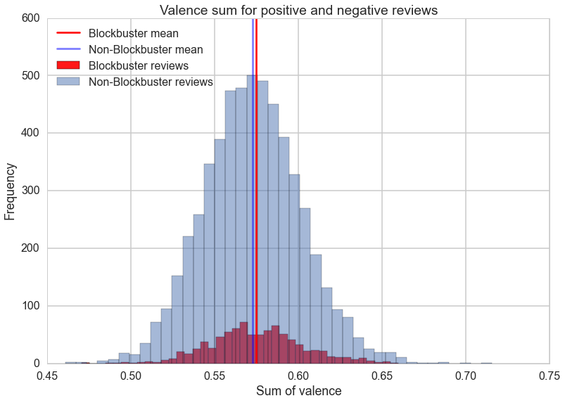

```python
graph_val_avg = plt.hist(dftouse.pct_scorables[dftouse.adj_opening_gross_bin ==1],bins=40,alpha=0.9,label="Blockbuster reviews",color="red")
graph_val_avg = plt.hist(dftouse.pct_scorables[dftouse.adj_opening_gross_bin ==0],bins=40,alpha=0.5,label="Non-Blockbuster reviews")
graph_val_avg = plt.axvline(x=dftouse.pct_scorables[dftouse.adj_opening_gross_bin ==1].mean(), color='red',alpha=0.9,label="Blockbuster mean")
graph_val_avg = plt.axvline(x=dftouse.pct_scorables[dftouse.adj_opening_gross_bin ==0].mean(), color='blue',alpha=0.5,label="Non-Blockbuster mean")

graph_val_avg = plt.title("Valence sum for positive and negative reviews")
graph_val_avg = plt.xlabel("Sum of valence")
graph_val_avg = plt.ylabel("Frequency")
graph_val_avg = plt.legend(loc='upper left')
```

```python
opening_gross = reviews_df.groupby("movie_id").adj_opening_gross.mean()
stars = reviews_df.groupby("movie_id").stars.mean()
```

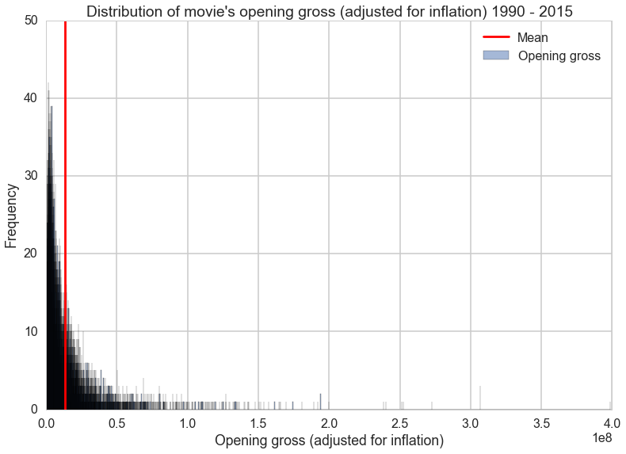

```python
plt.hist(opening_gross,bins=10000,alpha=0.5,label="Opening gross")
plt.axvline(x=opening_gross.mean(), label = "Mean", color = "r")

plt.ylim(0, 50)
plt.title("Distribution of movie's opening gross (adjusted for inflation) 1990 - 2015")
plt.xlabel("Opening gross (adjusted for inflation)")
plt.ylabel("Frequency")
plt.legend(loc='upper right')
```

Now by movie

```python
year_movies = reviews_df.groupby("movie_id").year.mean()
```

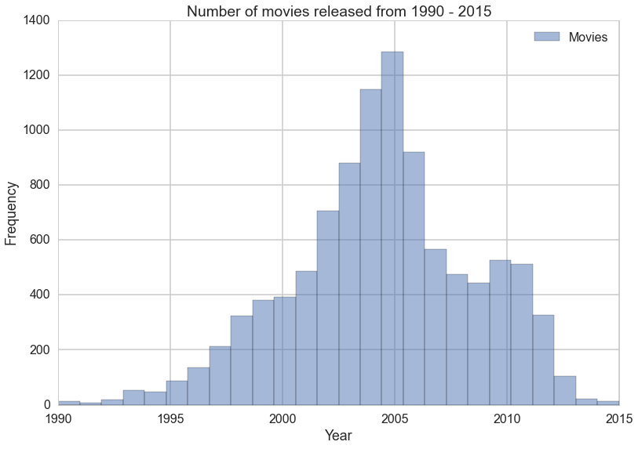

```python
plt.hist(year_movies, bins=26,alpha=0.5,label="Movies")
# plt.axhline(y=avg_number, label = "Mean", color = "b")

plt.title("Number of movies released from 1990 - 2015")
plt.xlabel("Year")
plt.ylabel("Frequency")
plt.legend(loc='upper right')
```

```python
opening_gross_2000s = reviews_df[reviews_df.year >=2000].groupby("movie_id").adj_opening_gross.mean()
opening_gross_1990s = reviews_df[reviews_df.year < 2000].groupby("movie_id").adj_opening_gross.mean()
```

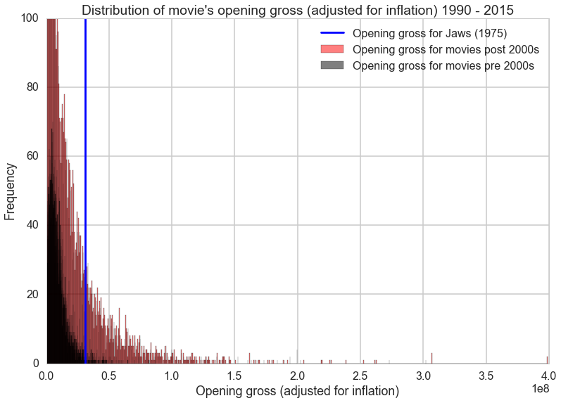

```python
plt.hist(opening_gross_2000s,bins=1000, alpha=0.5, color = "r", label="Opening gross for movies post 2000s")
plt.hist(opening_gross_1990s,bins=1000,alpha=0.5, color = "k", label="Opening gross for movies pre 2000s")
# plt.axvline(x=opening_gross.mean(), label = "Mean")
plt.axvline(x=31217400.17, label = "Opening gross for Jaws (1975)")

plt.ylim(0, 100)
plt.title("Distribution of movie's opening gross (adjusted for inflation) 1990 - 2015")
plt.xlabel("Opening gross (adjusted for inflation)")
plt.ylabel("Frequency")
plt.legend(loc='upper right')
```

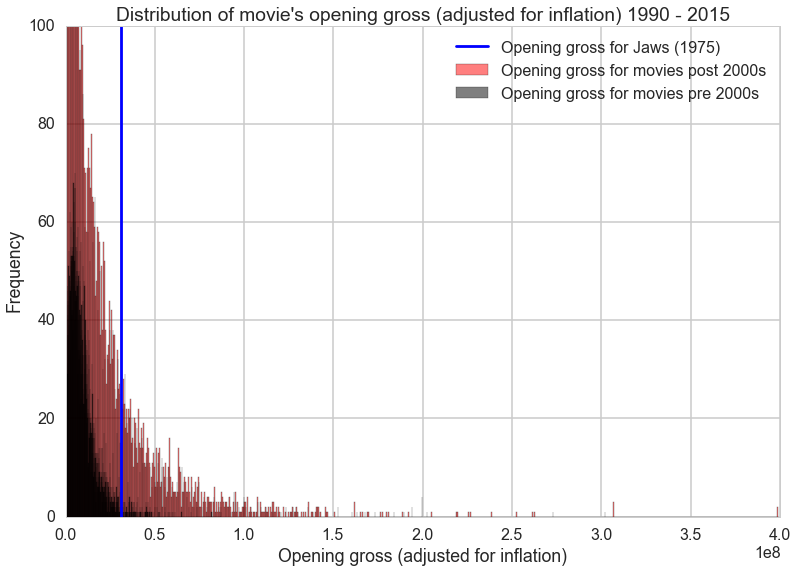

```python
plt.hist(opening_gross_2000s,bins=1000, alpha=0.5, color = "r", label="Opening gross for movies post 2000s")
plt.hist(opening_gross_1990s,bins=1000,alpha=0.5, color = "k", label="Opening gross for movies pre 2000s")
# plt.axvline(x=opening_gross.mean(), label = "Mean")
plt.axvline(x=31217400.17, label = "Opening gross for Jaws (1975)")

plt.ylim(0, 100)
plt.title("Distribution of movie's opening gross (adjusted for inflation) 1990 - 2015")
plt.xlabel("Opening gross (adjusted for inflation)")
plt.ylabel("Frequency")
plt.legend(loc='upper right')
```

```python
opening_gross_00s = reviews_df[reviews_df.year >=2000][reviews_df.year <2010].groupby("movie_id").adj_opening_gross.mean()
opening_gross_10s = reviews_df[reviews_df.year >=2010].groupby("movie_id").adj_opening_gross.mean()
```

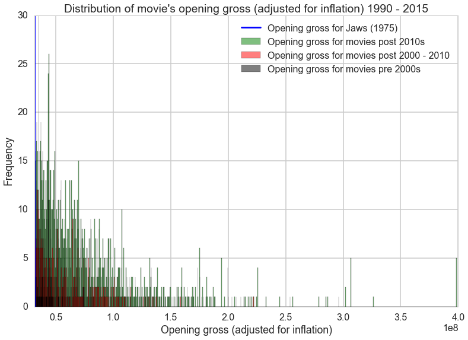

```python
plt.hist(opening_gross_10s,bins=1000, alpha=0.5, color = "g", label="Opening gross for movies post 2010s")
plt.hist(opening_gross_00s,bins=1000, alpha=0.5, color = "r", label="Opening gross for movies post 2000 - 2010")
plt.hist(opening_gross_1990s,bins=1000,alpha=0.5, color = "k", label="Opening gross for movies pre 2000s")
plt.axvline(x=31217400.17, label = "Opening gross for Jaws (1975)")

plt.ylim(0, 30)
plt.xlim(31217400.17,)
plt.title("Distribution of movie's opening gross (adjusted for inflation) 1990 - 2015")
plt.xlabel("Opening gross (adjusted for inflation)")
plt.ylabel("Frequency")
plt.legend(loc='upper right')
```

```python
review_count = reviews_df.groupby("movie_id").review_id.count()
```

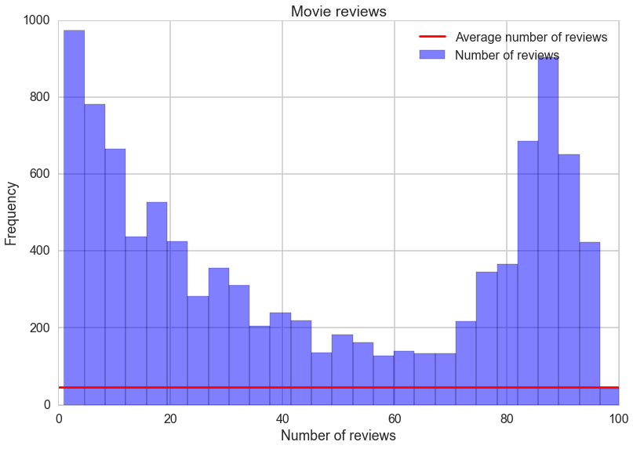

```python
plt.hist(review_count, bins = 50, alpha = 0.5, color = "b", label="Number of reviews")
plt.axhline(y=review_count.mean(), color = "r", label = "Average number of reviews")

plt.xlim(0,100)
plt.title("Movie reviews")
plt.xlabel("Number of reviews")
plt.ylabel("Frequency")
plt.legend(loc='upper right')
```

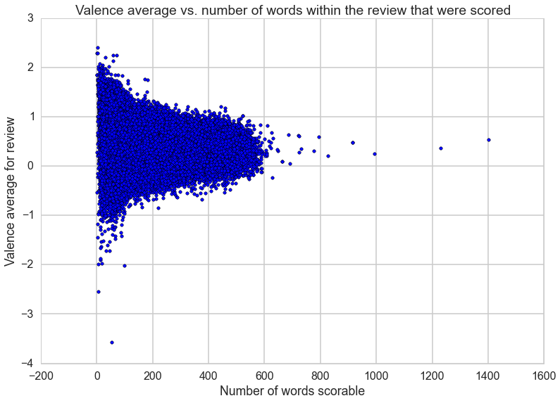

```python
plt.scatter(reviews_df.n_scorables, reviews_df.valence_avg)

plt.title("Valence average vs. number of words within the review that were scored")
plt.xlabel("Number of words scorable")
plt.ylabel("Valence average for review")
```

It looks like the more words there are in a review that is scorable the more likely the review is just neutral. This makes sense, and we'd hope that for reviews with the same valence score our sentiment analysis will have more differentiated probabilities -- suggesting that there is more nuance.

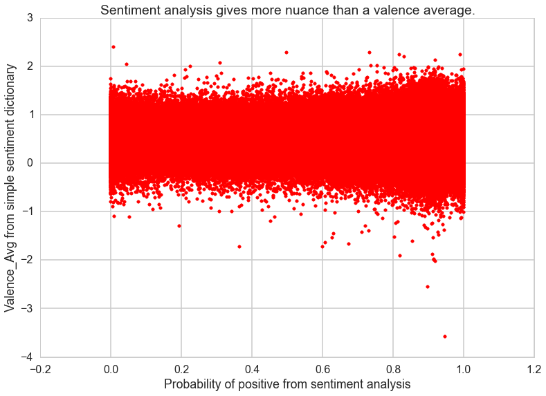

```python
plt.scatter(reviews_df["mean"], reviews_df["valence_avg"], color = "r")

plt.title("Sentiment analysis gives more nuance than a valence average.")
plt.xlabel("Probability of positive from sentiment analysis")
plt.ylabel("Valence_Avg from simple sentiment dictionary")
```

This confirms that our sentiment analysis indicators are more sensitive, which we hope will make them better regressors!

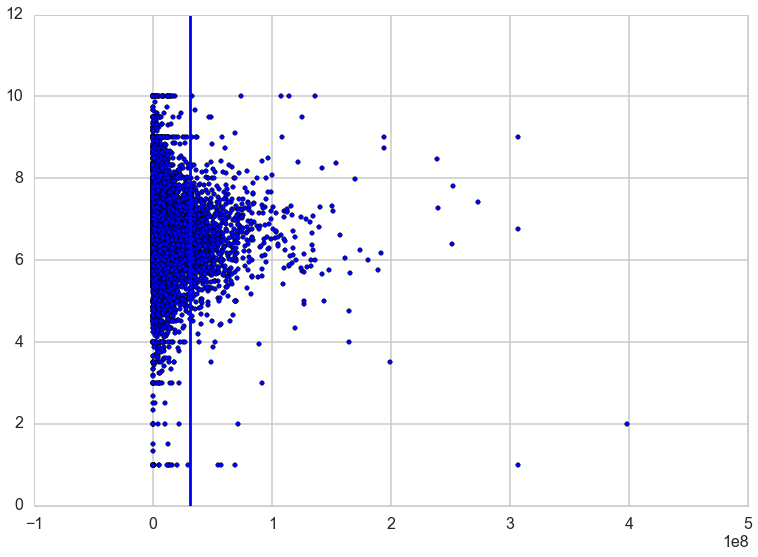

```python
plt.scatter(opening_gross, stars)
plt.axvline(x=31217400.17)
```

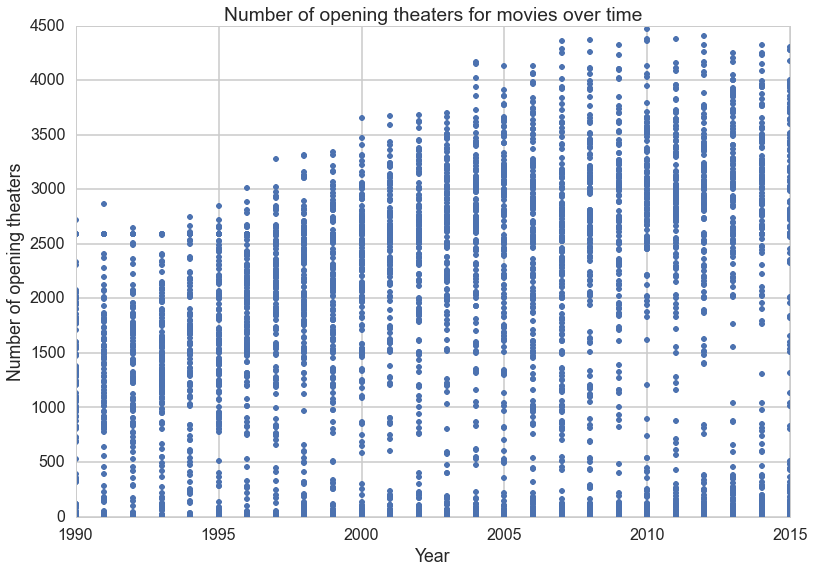

```python
year_theaters = dftouse.groupby('open_year')
mean_year_theaters = year_theaters['opening_theaters'].mean()
std_year_theaters=year_theaters['opening_theaters'].std()
decadesplot = plt.plot(dftouse.open_year,dftouse.opening_theaters,'.')
decadesplot= plt.xlabel("Year")
decadesplot= plt.ylabel("Number of opening theaters")
decadesplot= plt.title("Number of opening theaters for movies over time")
```

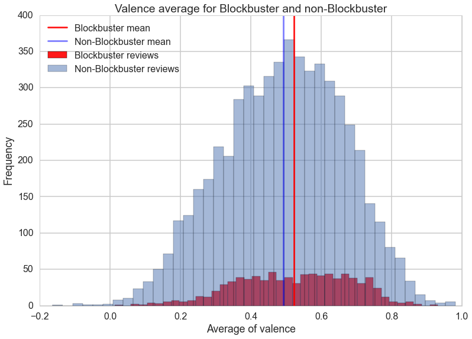

```python
graph_val_avg = plt.hist(dftouse.valence_avg[dftouse.adj_opening_gross_bin ==1],bins=40,alpha=0.9,label="Blockbuster reviews",color="red")
graph_val_avg = plt.hist(dftouse.valence_avg[dftouse.adj_opening_gross_bin ==0],bins=40,alpha=0.5,label="Non-Blockbuster reviews")
graph_val_avg = plt.axvline(x=dftouse.valence_avg[dftouse.adj_opening_gross_bin ==1].mean(), color='red',alpha=0.9,label="Blockbuster mean")
graph_val_avg = plt.axvline(x=dftouse.valence_avg[dftouse.adj_opening_gross_bin ==0].mean(), color='blue',alpha=0.5,label="Non-Blockbuster mean")

graph_val_avg = plt.title("Valence average for Blockbuster and non-Blockbuster")
graph_val_avg = plt.xlabel("Average of valence")
graph_val_avg = plt.ylabel("Frequency")
graph_val_avg = plt.legend(loc='upper left')
```

The above shows that average valence as calculated by LabMT is similar across Blockbuster and non-Blockbuster movies.

### Clustering movies

Looking at the regression results above, we can see our valence data is not strongly correlated with gross box office numbers. However, this does not imply that there is not a relationship between movie reviews and box office success. It is certainly possible that there are different underlying structures for various groups of movies in the world.

A neat way to discover these structures is to implement a Clustering Algorithm. Using the sklearn.mixture.GMM, we can determine if there are underlying Gaussian distributions in the population that is creating the patches of data we see in our sample. Thus, we can determine which subsets of our data we should be running our regressions on.

```python
Xall=dftouse[['valence_avg', 'adj_opening_gross']].values
from sklearn.mixture import GMM
n_clusters=2
clfgmm = GMM(n_components=n_clusters, covariance_type="tied")
clfgmm.fit(Xall)
print clfgmm
gmm_means=clfgmm.means_
gmm_covar=clfgmm.covars_
print gmm_means, gmm_covar
```

```
GMM(covariance_type='tied', init_params='wmc', min_covar=0.001,
  n_components=2, n_init=1, n_iter=100, params='wmc', random_state=None,
  thresh=None, tol=0.001)
[[  4.96446021e-01   8.93331897e+06]
 [  5.07113904e-01   1.29998776e+08]] [[  3.00979587e-02  -1.03986465e+05]
 [ -1.03986465e+05   2.97903076e+14]]
```

```python
from scipy import linalg

def plot_ellipse(splot, mean, cov, color):
    v, w = linalg.eigh(cov)
    u = w[0] / linalg.norm(w[0])
    angle = np.arctan(u[1] / u[0])
    angle = 180 * angle / np.pi  # convert to degrees
    # filled Gaussian at 2 standard deviation
    ell = mpl.patches.Ellipse(mean, 2 * v[0] ** 0.5, 2 * v[1] ** 0.5,
                              180 + angle, color=color, lw=3, fill=False)
    ell.set_clip_box(splot.bbox)
    ell1 = mpl.patches.Ellipse(mean, 1 * v[0] ** 0.5, 1 * v[1] ** 0.5,
                              180 + angle, color=color, lw=3, fill=False)
    ell1.set_clip_box(splot.bbox)
    ell3 = mpl.patches.Ellipse(mean, 3 * v[0] ** 0.5, 3 * v[1] ** 0.5,
                              180 + angle, color=color, lw=3, fill=False)
    ell3.set_clip_box(splot.bbox)
    #ell.set_alpha(0.2)
    splot.add_artist(ell)
    splot.add_artist(ell1)
    splot.add_artist(ell3)
```

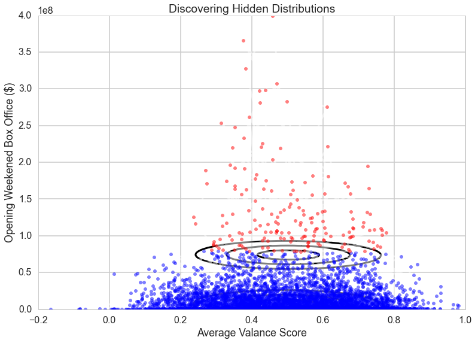

```python
plt.figure()
ax=plt.gca()
plot_ellipse(ax, gmm_means[0], gmm_covar, 'k')
plot_ellipse(ax, gmm_means[1], gmm_covar, 'k')
gmm_labels=clfgmm.predict(Xall)
for k, col in zip(range(n_clusters), ['blue','red']):
    my_members = gmm_labels == k
    ax.plot(Xall[my_members, 0], Xall[my_members, 1], 'w',
            markerfacecolor=col, marker='.', alpha=0.5)
plt.xlabel('Average Valance Score')
plt.ylabel('Opening Weekened Box Office ($)')
plt.title('Discovering Hidden Distributions')
```

However, the shapes of clusters still doesn't look very intuitive, and it looks like the current cluster is just trying to average out extreme values. Let's try to see if we would get a better result with 3 clusters:

```
GMM(covariance_type='tied', init_params='wmc', min_covar=0.001,
  n_components=2, n_init=1, n_iter=100, params='wmc', random_state=None,
  thresh=None, tol=0.001)
[[  4.96652363e-01   6.96859291e+06]
 [  5.02661289e-01   7.39133403e+07]
 [  4.64227407e-01   2.07888790e+08]] [[  3.00909368e-02  -4.08592198e+04]
 [ -4.08592198e+04   1.62697509e+14]]
```

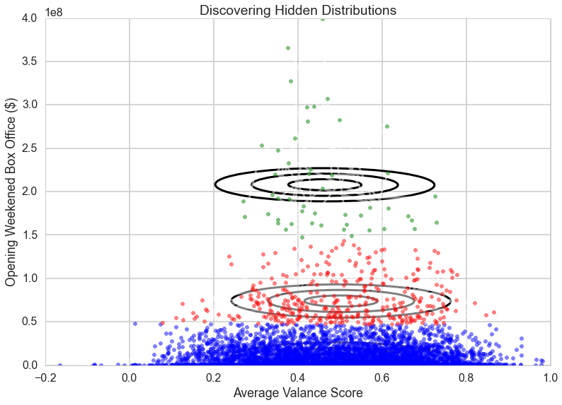

```python
n_clusters=3
clfgmm3 = GMM(n_components=n_clusters, covariance_type="tied")
clfgmm3.fit(Xall)
print clfgmm
gmm_means=clfgmm3.means_
gmm_covar=clfgmm3.covars_
print gmm_means, gmm_covar
plt.figure()
ax=plt.gca()
plot_ellipse(ax, gmm_means[0], gmm_covar, 'k')
plot_ellipse(ax, gmm_means[1], gmm_covar, 'k')
plot_ellipse(ax, gmm_means[2], gmm_covar, 'k')
gmm_labels=clfgmm3.predict(Xall)
for k, col in zip(range(n_clusters), ['blue','red', 'green']):
    my_members = gmm_labels == k
    ax.plot(Xall[my_members, 0], Xall[my_members, 1], 'w',
            markerfacecolor=col, marker='.', alpha=0.5)
plt.xlabel('Average Valance Score')
plt.ylabel('Opening Weekened Box Office ($)')
plt.title('Discovering Hidden Distributions')
```

Now, let's try 4

```
GMM(covariance_type='tied', init_params='wmc', min_covar=0.001,
  n_components=2, n_init=1, n_iter=100, params='wmc', random_state=None,
  thresh=None, tol=0.001)
[[  5.01607271e-01   6.54716889e+06]
 [  5.03587182e-01   7.54934876e+07]
 [  4.63665714e-01   2.08932630e+08]
 [  4.89778713e-01   7.82695570e+06]] [[  3.00582297e-02  -3.99804483e+04]
 [ -3.99804483e+04   1.64411009e+14]]
```

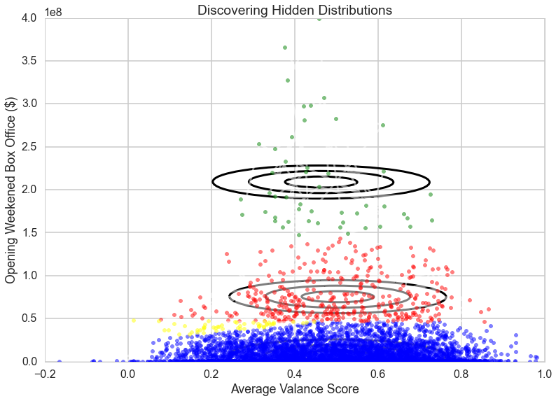

```python
n_clusters=4
clfgmm3 = GMM(n_components=n_clusters, covariance_type="tied")
clfgmm3.fit(Xall)
print clfgmm
gmm_means=clfgmm3.means_
gmm_covar=clfgmm3.covars_
print gmm_means, gmm_covar
plt.figure()
ax=plt.gca()
plot_ellipse(ax, gmm_means[0], gmm_covar, 'k')
plot_ellipse(ax, gmm_means[1], gmm_covar, 'k')
plot_ellipse(ax, gmm_means[2], gmm_covar, 'k')
gmm_labels=clfgmm3.predict(Xall)
for k, col in zip(range(n_clusters), ['blue','red', 'green', 'yellow']):
    my_members = gmm_labels == k
    ax.plot(Xall[my_members, 0], Xall[my_members, 1], 'w',
            markerfacecolor=col, marker='.', alpha=0.5)
plt.xlabel('Average Valance Score')
plt.ylabel('Opening Weekened Box Office ($)')
plt.title('Discovering Hidden Distributions')
```

Since there is so much overlap between the lower two clusters this time, we see that clustering into 3 groups is the better choice for our data. (We have also tried more clusters, but they similarly give worse results than the 3-clusters version)

# Analysis

### Visualization

We are going to use several regression methods, namely

1. Linear regression
2. Support Vector Machine Regression
3. Decision Tree Regression
4. Random Forest Regression
5. AdaBooster Regression
6. GradientBooster Regression

For methods 2-6, we will train these data and optimize it given some parameters. We will test the accuracy score of all of the classifiers and find the best one.

We begin by defining functions do_regress which takes a regressor from and feed it into the function cv_optimize to do optimization, then printing the training and testing accuracy scores. The function cv_optimize will help optimize the regressor given the parameters.

```python
def do_regress(clf, parameters, indf, featurenames, targetname, mask=None, reuse_split=None, score_func=None, n_folds=5, n_jobs=1):
    subdf=indf[featurenames]
    X=subdf.values
    y=indf[targetname]
    if mask !=None:
        print "using mask"
        Xtrain, Xtest, ytrain, ytest = X[mask], X[~mask], y[mask], y[~mask]
    if reuse_split !=None:
        print "using reuse split"
        Xtrain, Xtest, ytrain, ytest = reuse_split['Xtrain'], reuse_split['Xtest'], reuse_split['ytrain'], reuse_split['ytest']
    if parameters:
        clf = cv_optimize(clf, parameters, Xtrain, ytrain, n_jobs=n_jobs, n_folds=n_folds, score_func=score_func)
    clf=clf.fit(Xtrain, ytrain)
    training_accuracy = clf.score(Xtrain, ytrain)
    test_accuracy = clf.score(Xtest, ytest)
    print "############# based on standard predict ################"
    print "Accuracy on training data: %0.2f" % (training_accuracy)
    print "Accuracy on test data:     %0.2f" % (test_accuracy)
    print "########################################################"
    return clf, Xtrain, ytrain, Xtest, ytest
def cv_optimize(clf, parameters, X, y, n_jobs=1, n_folds=5, score_func=None):
    if score_func:
        gs = GridSearchCV(clf, param_grid=parameters, cv=n_folds, n_jobs=n_jobs, scoring=score_func)
    else:
        gs = GridSearchCV(clf, param_grid=parameters, n_jobs=n_jobs, cv=n_folds)
    gs.fit(X, y)
#     print "BEST", gs.best_params_, gs.best_score_, gs.grid_scores_
    best = gs.best_estimator_
    return best


# create training and testing sets
itrain, itest = train_test_split(xrange(dftouse.shape[0]), train_size=0.6)
mask_classify=np.ones(dftouse.shape[0], dtype='int')
mask_classify[itrain]=1
mask_classify[itest]=0
mask_classify = (mask_classify==1)

# define list of features to be trained over
Xnames = ['opening_theaters','pct_scorables','theaters','valence_avg_var','valence_sum','abs_valence_avg'
          ,'valence_avg','mean_t1','mean_t0','max_t1','max_t0']
```

```python
# linear regression
from sklearn.linear_model import LinearRegression

clflinear_reg = LinearRegression()

Xlin = dftouse[Xnames].values
ylin = dftouse['adj_opening_gross']
clflinear_reg = clflinear_reg.fit(Xlin[mask_classify], ylin[mask_classify])
training_accuracy = clflinear_reg.score(Xlin[mask_classify], ylin[mask_classify])
test_accuracy = clflinear_reg.score(Xlin[~mask_classify], ylin[~mask_classify])

print "############# based on standard predict ################"
print "Accuracy on training data: %0.2f" % (training_accuracy)
print "Accuracy on test data:     %0.2f" % (test_accuracy)
print "########################################################"
```

```
############# based on standard predict ################
Accuracy on training data: 0.49
Accuracy on test data:     0.47
########################################################
```

```python
%%time
# SVC regression

from sklearn.svm import SVR
parameters_svr = {"C": [0.001, 0.01, 0.1, 1, 10, 100]}
clfsvr_reg = SVR(kernel="linear")
clfsvr_reg, Xtrain, ytrain, Xtest, ytest = do_regress(clfsvr_reg, parameters_svr,
                                                       dftouse, Xnames, 'adj_opening_gross', mask=mask_classify)
```

```
using mask
############# based on standard predict ################
Accuracy on training data: 0.37
Accuracy on test data:     0.39
########################################################
CPU times: user 8min 18s, sys: 866 ms, total: 8min 19s
Wall time: 8min 20s
```

```python
# Tree regressor

from sklearn.tree import DecisionTreeRegressor
parameters_tree = {"max_depth": [1, 2, 3, 4, 5, 6], 'min_samples_leaf': [1, 2, 3, 4, 5, 6]}
clftree_reg = DecisionTreeRegressor()
clftree_reg, Xtrain, ytrain, Xtest, ytest = do_regress(clftree_reg, parameters_tree,
                                                       dftouse, Xnames, 'adj_opening_gross', mask=mask_classify)
```

```
using mask
############# based on standard predict ################
Accuracy on training data: 0.86
Accuracy on test data:     0.79
########################################################
```

```python
# Random forest regression

from sklearn.ensemble import RandomForestRegressor
parameters_forest = {"n_estimators": range(1, len(Xnames))}
clfforest_1 = RandomForestRegressor()
clfforest_1, Xtrain, ytrain, Xtest, ytest = do_regress(clfforest_1, parameters_forest,
                                                       dftouse, Xnames, 'adj_opening_gross', mask=mask_classify)
```

```
using mask
############# based on standard predict ################
Accuracy on training data: 0.97
Accuracy on test data:     0.81
########################################################
```

```python
# AdaBoost Regression
from sklearn.ensemble import AdaBoostRegressor
clfAda_regress = AdaBoostRegressor()

parameters_adaboost = {"n_estimators": range(20, 60)}
clfAda_regress, Xtrain, ytrain, Xtest, ytest = do_regress(clfAda_regress, parameters_adaboost,
                                                       dftouse, Xnames, 'adj_opening_gross_bin',
                                                          mask=mask_classify)
```

```
using mask
############# based on standard predict ################
Accuracy on training data: 0.65
Accuracy on test data:     0.61
########################################################
```

```python
from sklearn.ensemble import GradientBoostingRegressor

clfGB_regress = GradientBoostingRegressor()

parameters_GB = {"n_estimators": range(30, 60), "max_depth": [1, 2, 3, 4, 5]}
clfGB_regress, Xtrain, ytrain, Xtest, ytest = do_regress(clfGB_regress, parameters_GB,
                                                       dftouse, Xnames, 'adj_opening_gross_bin'
                                                  , mask=mask_classify)
```

```
using mask
############# based on standard predict ################
Accuracy on training data: 0.78
Accuracy on test data:     0.69
########################################################
```

##### Classification

We are also interested in classifying whether movies are blockbusters or not, which is defined as having a grossing of over 100M. We would like to see to what extent can our sentiment analysis predict whether a given movie has been a blockbuser.

We will first train classifiers on two variables, our valence average scores for topic 1 and topic 0. This is because we are interested in seeing to what extent our bag of words analysis has produced valences of reviews that have predictive powers. We will also train classifiers on two other variabels, namely average valence from LabMT and number of theaters showing film and compare. The classifiers we will be using are the following:

1) Logistic regression 2) Support Vector Machine 3) Decision tree classifier 4) AdaBoost classifier 5) GradientBooster classifier

With these classifiers we will visualize how these classifiers perform through a contour plot. We will also compare how these classifiers compare to each other using ROC curves.

We will also split betwen training and testing sets and choose the classifier that performs best on the testing set.

Again, we will split between training and testing set and select the classifier that performs the best on the testing set. We will visualize how well the classifiers perform using a ROC curve.

Let's define all the functions needed to do classificaiton. We write one main function called do_classify that inputs a classifier, data to train over and outputs the performance of accuracy score of the classifier on test and training data as well as the confusion matrix. We write a function called cv_optimize that optimizes a classifier given the parameters that are fed into it. We also create functions to make ROC curves, contour plots and tree contours.

```python
from sklearn.svm import LinearSVC
from sklearn.grid_search import GridSearchCV
from sklearn.cross_validation import train_test_split
from sklearn.metrics import confusion_matrix
from matplotlib.colors import ListedColormap
from sklearn.linear_model import LogisticRegression

def do_classify(clf, parameters, indf, featurenames, targetname, target1val, mask=None, reuse_split=None, score_func=None, n_folds=5, n_jobs=1):
    subdf=indf[featurenames]
    X=subdf.values
    y=(indf[targetname].values==target1val)*1
    print clf.__class__
    if mask !=None:
        print "using mask"
        Xtrain, Xtest, ytrain, ytest = X[mask], X[~mask], y[mask], y[~mask]
    if reuse_split !=None:
        print "using reuse split"
        Xtrain, Xtest, ytrain, ytest = reuse_split['Xtrain'], reuse_split['Xtest'], reuse_split['ytrain'], reuse_split['ytest']
    if parameters:
        clf = cv_optimize(clf, parameters, Xtrain, ytrain, n_jobs=n_jobs, n_folds=n_folds, score_func=score_func)
    clf=clf.fit(Xtrain, ytrain)
    training_accuracy = clf.score(Xtrain, ytrain)
    test_accuracy = clf.score(Xtest, ytest)
    print "############# based on standard predict ################"
    print "Accuracy on training data: %0.2f" % (training_accuracy)
    print "Accuracy on test data:     %0.2f" % (test_accuracy)
    print confusion_matrix(ytest, clf.predict(Xtest))
    print "########################################################"
    return clf, Xtrain, ytrain, Xtest, ytest
```

```python
cmap_light = ListedColormap(['#FFAAAA', '#AAFFAA', '#AAAAFF'])
cmap_bold = ListedColormap(['#FF0000', '#00FF00', '#0000FF'])
cm = plt.cm.RdBu
cm_bright = ListedColormap(['#FF0000', '#0000FF'])

def points_plot(ax, Xtr, Xte, ytr, yte, clf, mesh=True, colorscale=cmap_light, cdiscrete=cmap_bold, alpha=0.3, psize=10, zfunc=False):
    h = .02
    X=np.concatenate((Xtr, Xte))
    x_min, x_max = X[:, 0].min() - .5, X[:, 0].max() + .5
    y_min, y_max = X[:, 1].min() - .5, X[:, 1].max() + .5
    xx, yy = np.meshgrid(np.linspace(x_min, x_max, 100),
                         np.linspace(y_min, y_max, 100))

    #plt.figure(figsize=(10,6))
    if mesh:
        if zfunc:
            p0 = clf.predict_proba(np.c_[xx.ravel(), yy.ravel()])[:, 0]
            p1 = clf.predict_proba(np.c_[xx.ravel(), yy.ravel()])[:, 1]
            Z=zfunc(p0, p1)
        else:
            Z = clf.predict(np.c_[xx.ravel(), yy.ravel()])
        Z = Z.reshape(xx.shape)
        plt.pcolormesh(xx, yy, Z, cmap=cmap_light, alpha=alpha, axes=ax)
    ax.scatter(Xtr[:, 0], Xtr[:, 1], c=ytr-1, cmap=cmap_bold, s=psize, alpha=alpha,edgecolor="k")
    # and testing points
    yact=clf.predict(Xte)
    ax.scatter(Xte[:, 0], Xte[:, 1], c=yte-1, cmap=cmap_bold, alpha=alpha, marker="s", s=psize+10)
    ax.set_xlim(xx.min(), xx.max())
    ax.set_ylim(yy.min(), yy.max())
    return ax,xx,yy
```

```python
def points_plot_prob(ax, Xtr, Xte, ytr, yte, clf, colorscale=cmap_light, cdiscrete=cmap_bold, ccolor=cm, psize=10, alpha=0.1, prob=True):
    ax,xx,yy = points_plot(ax, Xtr, Xte, ytr, yte, clf, mesh=False, colorscale=colorscale, cdiscrete=cdiscrete, psize=psize, alpha=alpha)
    if prob:
        Z = clf.predict_proba(np.c_[xx.ravel(), yy.ravel()])[:, 1]
    else:
        Z = clf.decision_function(np.c_[xx.ravel(), yy.ravel()])
    Z = Z.reshape(xx.shape)
    plt.contourf(xx, yy, Z, cmap=ccolor, alpha=.2, axes=ax)
    cs2 = plt.contour(xx, yy, Z, cmap=ccolor, alpha=.6, axes=ax)
    plt.clabel(cs2, fmt = '%2.1f', colors = 'k', fontsize=14, axes=ax)
    plt.title(clf.__class__)
    return ax
```

```python
from sklearn.metrics import roc_curve, auc

def make_roc(name, clf, ytest, xtest, ax=None, labe=5, proba=True, skip=0):
    initial=False
    if not ax:
        ax=plt.gca()
        initial=True
    if proba:
        fpr, tpr, thresholds=roc_curve(ytest, clf.predict_proba(xtest)[:,1])
    else:
        fpr, tpr, thresholds=roc_curve(ytest, clf.decision_function(xtest))
    roc_auc = auc(fpr, tpr)
    if skip:
        l=fpr.shape[0]
        ax.plot(fpr[0:l:skip], tpr[0:l:skip], '.-', alpha=0.3, label='ROC curve for %s (area = %0.2f)' % (name, roc_auc))
    else:
        ax.plot(fpr, tpr, '.-', alpha=0.3, label='ROC curve for %s (area = %0.2f)' % (name, roc_auc))
    label_kwargs = {}
    label_kwargs['bbox'] = dict(
        boxstyle='round,pad=0.3', alpha=0.2,
    )
    for k in xrange(0, fpr.shape[0],labe):
        #from https://gist.github.com/podshumok/c1d1c9394335d86255b8
        threshold = str(np.round(thresholds[k], 2))
        ax.annotate(threshold, (fpr[k], tpr[k]), **label_kwargs)
    if initial:
        ax.plot([0, 1], [0, 1], 'k--')
        ax.set_xlim([0.0, 1.0])
        ax.set_ylim([0.0, 1.05])
        ax.set_xlabel('False Positive Rate')
        ax.set_ylabel('True Positive Rate')
        ax.set_title('ROC using many features')
    ax.legend(loc="lower right")
    return ax
```

```python
def plot_2tree(ax, Xtr, Xte, ytr, yte, clf, plot_train = True, plot_test = True, lab = ['Feature 1', 'Feature 2'], mesh=True, colorscale=cmap_light, cdiscrete=cmap_bold, alpha=0.3, psize=10, zfunc=False):
    # Create a meshgrid as our test data
    plt.figure(figsize=(15,10))
    plot_step= 0.05
    xmin, xmax= Xtr[:,0].min(), Xtr[:,0].max()
    ymin, ymax= Xtr[:,1].min(), Xtr[:,1].max()
    xx, yy = np.meshgrid(np.arange(xmin, xmax, plot_step), np.arange(ymin, ymax, plot_step))

    # Re-cast every coordinate in the meshgrid as a 2D point
    Xplot= np.c_[xx.ravel(), yy.ravel()]


    # Predict the class
    Z = clfTree1.predict( Xplot )

    # Re-shape the results
    Z= Z.reshape(xx.shape)
    cs = plt.contourf(xx, yy, Z, cmap= cmap_light, alpha=0.3)

    # Overlay training samples
    if (plot_train == True):
        plt.scatter(Xtr[:, 0], Xtr[:, 1], c=ytr-1, cmap=cmap_bold, alpha=alpha,edgecolor="k")
    # and testing points
    if (plot_test == True):
        plt.scatter(Xte[:, 0], Xte[:, 1], c=yte-1, cmap=cmap_bold, alpha=alpha, marker="s")

    plt.xlabel(lab[0])
    plt.ylabel(lab[1])
    plt.title("Boundary for decision tree classifier",fontsize=20)
```

```python
%%time

two_features_bow = ['mean_t1','mean_t0']

clflog1 = LogisticRegression()
parameters_log = {"C": [0.000000001, 0.00000001, 0.000001, 0.00001, 0.0001, 0.001, 0.01, 0.1, 1, 10, 100,]}
clflog1, Xtrain, ytrain, Xtest, ytest=do_classify(clflog1, parameters_log, dftouse,
                                                 two_features_bow,
                                                 'adj_opening_gross_bin', 1, mask=mask_classify)
print ""


from sklearn.svm import SVC
clfsvm1 = SVC(kernel="linear")
parameters_svc = {"C": [0.001, 0.01, 0.1, 1, 10, 100, 1000]}
clfsvm1, Xtrain, ytrain, Xtest, ytest=do_classify(clfsvm1, parameters_svc, dftouse,
                                                 two_features_bow,
                                                 'adj_opening_gross_bin', 1, mask=mask_classify)

print ""

from sklearn import tree
clfTree1 = tree.DecisionTreeClassifier()

parameters_tree = {"max_depth": [1, 2, 3, 4, 5, 6, 7], 'min_samples_leaf': [1, 2, 3, 4, 5, 6]}

clfTree1, Xtrain, ytrain, Xtest, ytest=do_classify(clfTree1, parameters_tree, dftouse,
                                                 two_features,
                                                 'adj_opening_gross_bin', 1, mask=mask_classify)

print ""



from sklearn.ensemble import AdaBoostClassifier

clfAda1 = AdaBoostClassifier()

parameters_adaboost = {"n_estimators": range(10, 60)}
clfAda1, Xtrain, ytrain, Xtest, ytest = do_classify(clfAda1, parameters_adaboost,
                                                       dftouse, two_features, 'adj_opening_gross_bin',
                                                   1, mask=mask_classify)

print ""


from sklearn.ensemble import GradientBoostingClassifier

clfGB1 = GradientBoostingClassifier()

parameters_GB = {"n_estimators": range(30, 60), "max_depth": [1, 2, 3, 4, 5]}
clfGB1, Xtrain, ytrain, Xtest, ytest = do_classify(clfGB1, parameters_GB,
                                                       dftouse, two_features, 'adj_opening_gross_bin', 1
                                                  , mask=mask_classify)
```

```
<class 'sklearn.linear_model.logistic.LogisticRegression'>
using mask
############# based on standard predict ################
Accuracy on training data: 0.87
Accuracy on test data:     0.86
[[2235    0]
 [ 357    0]]
########################################################

<class 'sklearn.svm.classes.SVC'>
using mask
############# based on standard predict ################
Accuracy on training data: 0.87
Accuracy on test data:     0.86
[[2235    0]
 [ 357    0]]
########################################################

<class 'sklearn.tree.tree.DecisionTreeClassifier'>
using mask
############# based on standard predict ################
Accuracy on training data: 0.87
Accuracy on test data:     0.86
[[2235    0]
 [ 357    0]]
########################################################

<class 'sklearn.ensemble.weight_boosting.AdaBoostClassifier'>
using mask
############# based on standard predict ################
Accuracy on training data: 0.87
Accuracy on test data:     0.86
[[2235    0]
 [ 357    0]]
########################################################

<class 'sklearn.ensemble.gradient_boosting.GradientBoostingClassifier'>
using mask
############# based on standard predict ################
Accuracy on training data: 0.87
Accuracy on test data:     0.86
[[2235    0]
 [ 357    0]]
########################################################
CPU times: user 3min 14s, sys: 324 ms, total: 3min 15s
Wall time: 3min 15s
```

Now let's print out the contour plots, accuracy scores and ROC curves to see which classifier performed the best

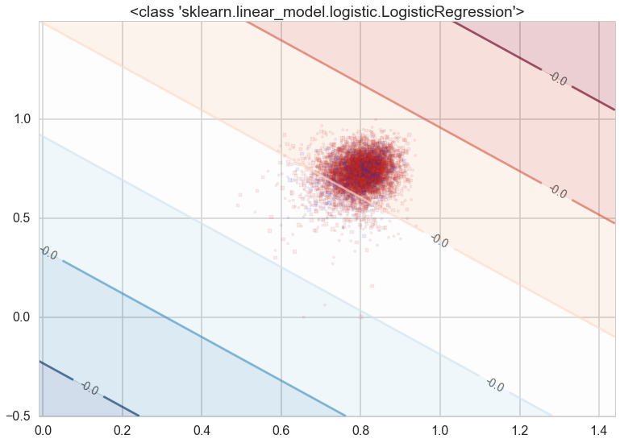

```python
Xtr=np.concatenate((Xtrain, Xtest))
plt.figure()
ax=plt.gca()
points_plot_prob(ax, Xtrain, Xtest, ytrain, ytest, clflog1, prob=False);
```

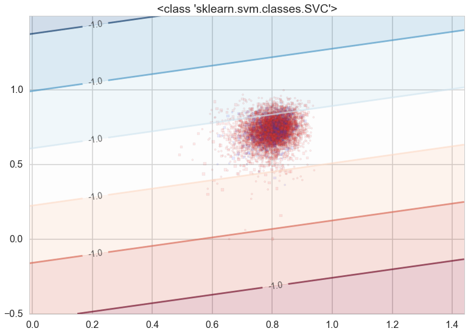

```python
Xtr=np.concatenate((Xtrain, Xtest))
plt.figure()
ax=plt.gca()
points_plot_prob(ax, Xtrain, Xtest, ytrain, ytest, clfsvm1, prob=False);
```

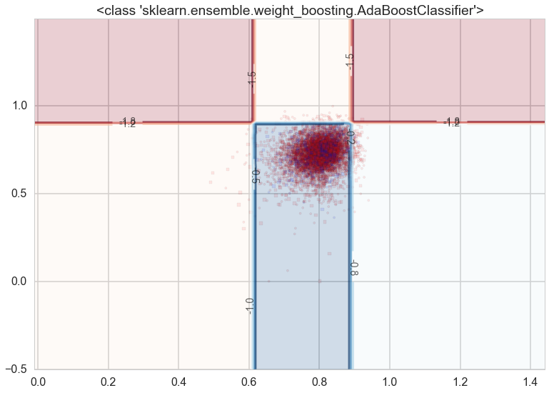

```python
Xtr=np.concatenate((Xtrain, Xtest))
plt.figure()
ax=plt.gca()
points_plot_prob(ax, Xtrain, Xtest, ytrain, ytest, clfAda1, prob=False);
```

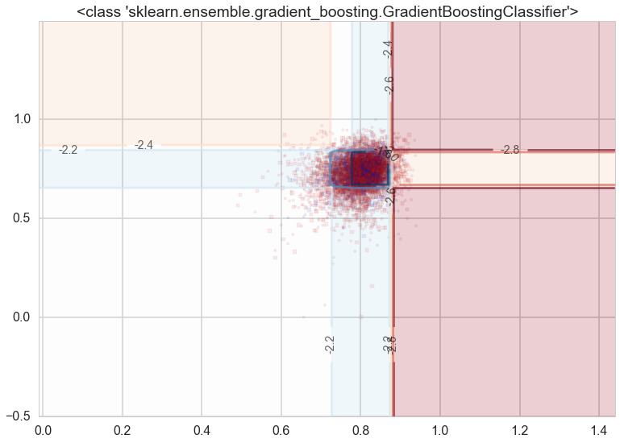

```python
Xtr=np.concatenate((Xtrain, Xtest))
plt.figure()
ax=plt.gca()
points_plot_prob(ax, Xtrain, Xtest, ytrain, ytest, clfGB1, prob=False);
```

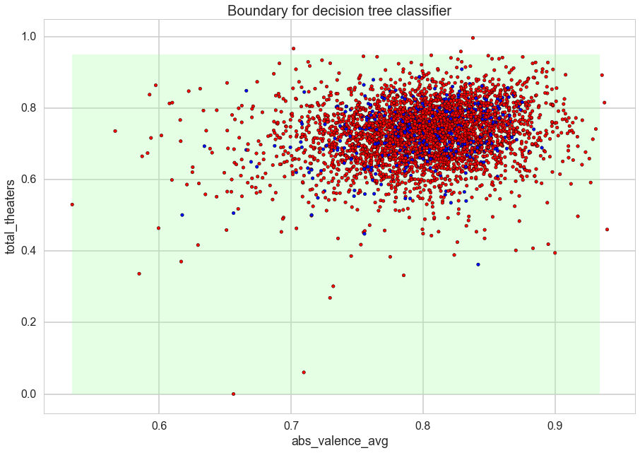

```python
plot_2tree(plt, Xtrain, Xtest, ytrain, ytest, clfTree1,
           lab = ['abs_valence_avg','total_theaters'], alpha = 1, plot_test = False)
```

Let's try plotting the ROC and see which classifier performs better.

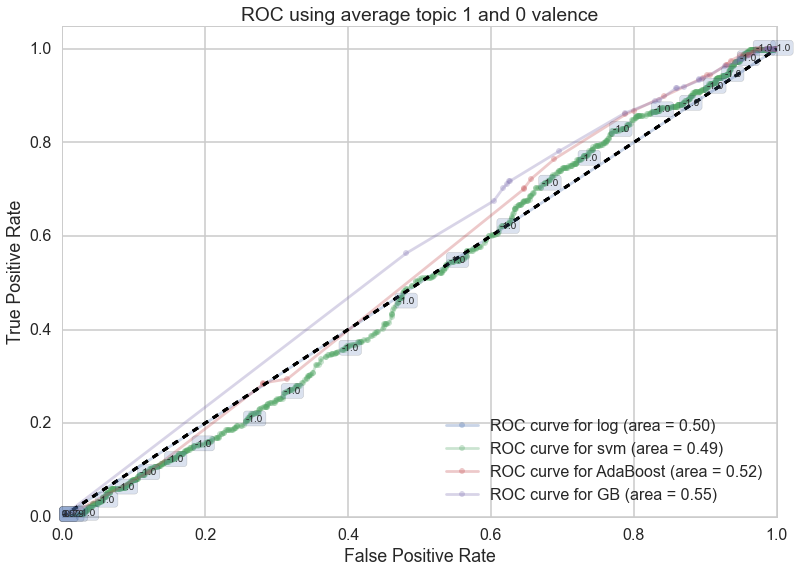

```python
ax1=make_roc("log", clflog1, ytest, Xtest, proba=True,labe=50)
ax1=make_roc("svm", clfsvm1, ytest, Xtest,proba=False,labe=50)
ax1=make_roc("AdaBoost", clfAda1, ytest, Xtest, proba=False,labe=50)
ax1=make_roc("GB", clfGB1, ytest, Xtest,proba=False,labe=50)
```

It seems as though if average valence for topic 1 and 2 are very poor features to train classifiers on, as all classifiers predict no blockbusters and only non-blockbusters. The ROC curve also give us inconclusive results, but the GB classifier seems marginally better than the rest.

Now we classify on another set of two variables, which is average valence from LabMT and number of theaters showing movie.

```python
two_features2 = ['valence_avg','theaters']

clflog12 = LogisticRegression()
parameters_log = {"C": [0.000000001, 0.00000001, 0.000001, 0.00001, 0.0001, 0.001, 0.01, 0.1, 1, 10, 100,]}
clflog12, Xtrain, ytrain, Xtest, ytest=do_classify(clflog12, parameters_log, dftouse,
                                                 two_features2,
                                                 'adj_opening_gross_bin', 1, mask=mask_classify)
print ""


from sklearn.svm import SVC
clfsvm12 = SVC(kernel="linear")
parameters_svc = {"C": [0.001, 0.01, 0.1, 1, 10, 100, 1000]}
clfsvm12, Xtrain, ytrain, Xtest, ytest=do_classify(clfsvm12, parameters_svc, dftouse,
                                                 two_features2,
                                                 'adj_opening_gross_bin', 1, mask=mask_classify)

print ""

from sklearn import tree
clfTree12 = tree.DecisionTreeClassifier()

parameters_tree = {"max_depth": [1, 2, 3, 4, 5, 6, 7], 'min_samples_leaf': [1, 2, 3, 4, 5, 6]}

clfTree12, Xtrain, ytrain, Xtest, ytest=do_classify(clfTree12, parameters_tree, dftouse,
                                                 two_features2,
                                                 'adj_opening_gross_bin', 1, mask=mask_classify)

print ""



from sklearn.ensemble import AdaBoostClassifier

clfAda12 = AdaBoostClassifier()

parameters_adaboost = {"n_estimators": range(10, 60)}
clfAda12, Xtrain, ytrain, Xtest, ytest = do_classify(clfAda12, parameters_adaboost,
                                                       dftouse, two_features2, 'adj_opening_gross_bin',
                                                   1, mask=mask_classify)

print ""


from sklearn.ensemble import GradientBoostingClassifier

clfGB12 = GradientBoostingClassifier()

parameters_GB = {"n_estimators": range(30, 60), "max_depth": [1, 2, 3, 4, 5]}
clfGB12, Xtrain, ytrain, Xtest, ytest = do_classify(clfGB12, parameters_GB,
                                                       dftouse, two_features2, 'adj_opening_gross_bin', 1
                                                  , mask=mask_classify)
```

```
<class 'sklearn.linear_model.logistic.LogisticRegression'>
using mask
############# based on standard predict ################
Accuracy on training data: 0.92
Accuracy on test data:     0.93
[[2178   57]
 [ 135  222]]
########################################################

<class 'sklearn.svm.classes.SVC'>
using mask
############# based on standard predict ################
Accuracy on training data: 0.93
Accuracy on test data:     0.93
[[2183   52]
 [ 131  226]]
########################################################

<class 'sklearn.tree.tree.DecisionTreeClassifier'>
using mask
############# based on standard predict ################
Accuracy on training data: 0.93
Accuracy on test data:     0.92
[[2178   57]
 [ 139  218]]
########################################################

<class 'sklearn.ensemble.weight_boosting.AdaBoostClassifier'>
using mask
############# based on standard predict ################
Accuracy on training data: 0.93
Accuracy on test data:     0.92
[[2173   62]
 [ 134  223]]
########################################################

<class 'sklearn.ensemble.gradient_boosting.GradientBoostingClassifier'>
using mask
############# based on standard predict ################
Accuracy on training data: 0.93
Accuracy on test data:     0.93
[[2183   52]
 [ 136  221]]
########################################################
```

[figure not shown]

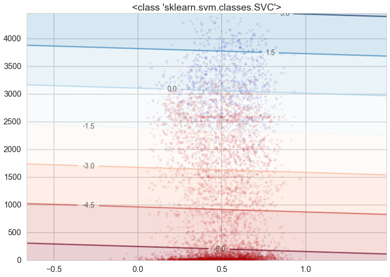

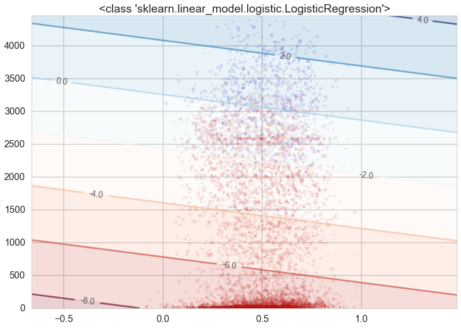

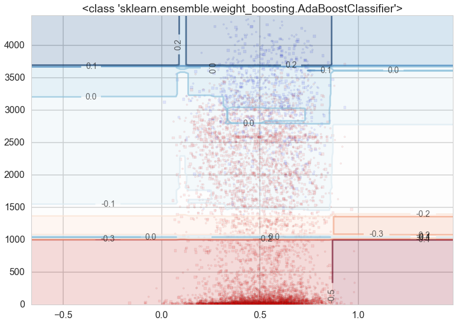

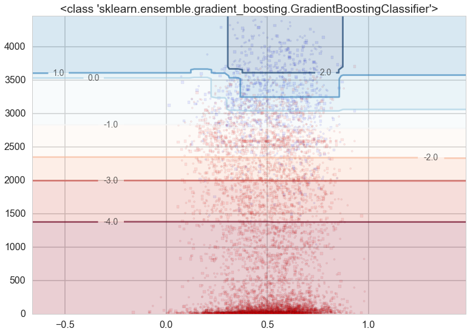

```python
classifiers2 = [clfsvm12,clflog12,clfAda12,clfGB12]

fig, axes = plt.subplots(nrows = len(classifiers2), ncols = 1, figsize=(40, 40))
for (ax, x) in zip(axes.ravel(), classifiers2):
    Xtr=np.concatenate((Xtrain, Xtest))
    plt.figure()
    ax=plt.gca()
    points_plot_prob(ax, Xtrain, Xtest, ytrain, ytest, x,prob=False);
```

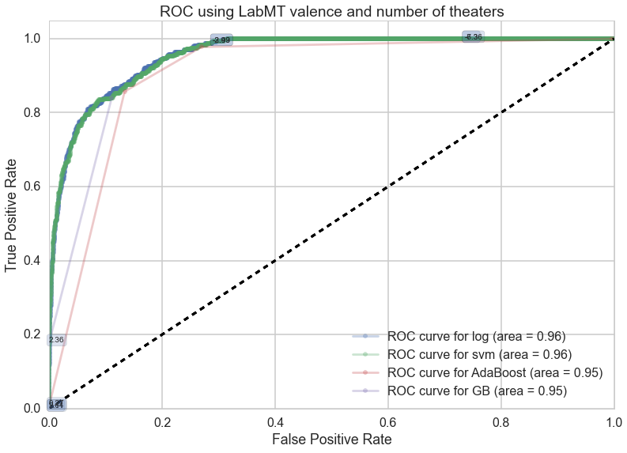

```python
ax1=make_roc("log", clflog12, ytest, Xtest, proba=False,labe=1000)
ax1=make_roc("svm", clfsvm12, ytest, Xtest,proba=False,labe=1000)
ax1=make_roc("AdaBoost", clfAda12, ytest, Xtest, proba=False,skip=50,labe=1000)
ax1=make_roc("GB", clfGB12, ytest, Xtest,proba=False,skip=50,labe=1000)
```

We see that all the classifiers have very similar accuracy scores so it is difficult to differentiate between which classifiers perform better. These two features have more predictive power than the previous two, which comes mostly from the feature for number of theaters. LabMT valence score lends very little predictive power.

```python
Xnames = ['opening_theaters','pct_scorables','theaters','valence_avg_var','valence_sum','abs_valence_avg'
          ,'valence_avg','mean_t1','mean_t0','max_t1','max_t0']
clflog2 = LogisticRegression()
parameters_log = {"C": [0.000001, 0.00001, 0.0001, 0.001, 0.01, 0.1, 1, 10, 100]}
clflog2, Xtrain, ytrain, Xtest, ytest=do_classify(clflog2, parameters_log, dftouse,
                                                 Xnames,'adj_opening_gross_bin', 1, mask=mask_classify)
print ""


from sklearn.svm import SVC
clfsvm2 = SVC(kernel="linear")
parameters_svc = {"C": [0.001, 0.01, 0.1, 1, 10, 100, 1000]}
clfsvm2, Xtrain, ytrain, Xtest, ytest=do_classify(clfsvm2, parameters_svc, dftouse,
                                                 Xnames,'adj_opening_gross_bin', 1, mask=mask_classify)

print ""

from sklearn import tree
clfTree2 = tree.DecisionTreeClassifier()

parameters_tree = {"max_depth": [1, 2, 3, 4, 5, 6, 7], 'min_samples_leaf': [1, 2, 3, 4, 5, 6]}

clfTree2, Xtrain, ytrain, Xtest, ytest=do_classify(clfTree2, parameters_tree, dftouse,
                                                 Xnames,'adj_opening_gross_bin', 1, mask=mask_classify)

print ""



from sklearn.ensemble import AdaBoostClassifier

clfAda2 = AdaBoostClassifier()

parameters_adaboost = {"n_estimators": range(10, 60)}
clfAda2, Xtrain, ytrain, Xtest, ytest = do_classify(clfAda2, parameters_adaboost,
                                                       dftouse, Xnames, 'adj_opening_gross_bin',
                                                   1, mask=mask_classify)

print ""


from sklearn.ensemble import GradientBoostingClassifier

clfGB2 = GradientBoostingClassifier()

parameters_GB = {"n_estimators": range(30, 60), "max_depth": [1, 2, 3, 4, 5]}
clfGB2, Xtrain, ytrain, Xtest, ytest = do_classify(clfGB2, parameters_GB, dftouse,
                                                   Xnames, 'adj_opening_gross_bin', 1, mask=mask_classify)
```

```
<class 'sklearn.linear_model.logistic.LogisticRegression'>
using mask
############# based on standard predict ################
Accuracy on training data: 0.93
Accuracy on test data:     0.93
[[2179   56]
 [ 129  228]]
########################################################

<class 'sklearn.svm.classes.SVC'>
using mask
############# based on standard predict ################
Accuracy on training data: 0.93
Accuracy on test data:     0.94
[[2184   51]
 [ 117  240]]
########################################################

<class 'sklearn.tree.tree.DecisionTreeClassifier'>
using mask
############# based on standard predict ################
Accuracy on training data: 0.94
Accuracy on test data:     0.93
[[2167   68]
 [ 116  241]]
########################################################

<class 'sklearn.ensemble.weight_boosting.AdaBoostClassifier'>
using mask
############# based on standard predict ################
Accuracy on training data: 0.94
Accuracy on test data:     0.93
[[2182   53]
 [ 122  235]]
########################################################

<class 'sklearn.ensemble.gradient_boosting.GradientBoostingClassifier'>
using mask
############# based on standard predict ################
Accuracy on training data: 0.96
Accuracy on test data:     0.93
[[2181   54]
 [ 117  240]]
########################################################
```

```python
Xnames = ['opening_theaters','pct_scorables','theaters','valence_avg_var','valence_sum','abs_valence_avg'
          ,'valence_avg','mean_t1','mean_t0','max_t1','max_t0']
clflog2 = LogisticRegression()
parameters_log = {"C": [0.000001, 0.00001, 0.0001, 0.001, 0.01, 0.1, 1, 10, 100]}
clflog2, Xtrain, ytrain, Xtest, ytest=do_classify(clflog2, parameters_log, dftouse,
                                                 Xnames,'adj_opening_gross_bin', 1, mask=mask_classify)
print ""


from sklearn.svm import SVC
clfsvm2 = SVC(kernel="linear")
parameters_svc = {"C": [0.001, 0.01, 0.1, 1, 10, 100, 1000]}
clfsvm2, Xtrain, ytrain, Xtest, ytest=do_classify(clfsvm2, parameters_svc, dftouse,
                                                 Xnames,'adj_opening_gross_bin', 1, mask=mask_classify)

print ""

from sklearn import tree
clfTree2 = tree.DecisionTreeClassifier()

parameters_tree = {"max_depth": [1, 2, 3, 4, 5, 6, 7], 'min_samples_leaf': [1, 2, 3, 4, 5, 6]}

clfTree2, Xtrain, ytrain, Xtest, ytest=do_classify(clfTree2, parameters_tree, dftouse,
                                                 Xnames,'adj_opening_gross_bin', 1, mask=mask_classify)

print ""



from sklearn.ensemble import AdaBoostClassifier

clfAda2 = AdaBoostClassifier()

parameters_adaboost = {"n_estimators": range(10, 60)}
clfAda2, Xtrain, ytrain, Xtest, ytest = do_classify(clfAda2, parameters_adaboost,
                                                       dftouse, Xnames, 'adj_opening_gross_bin',
                                                   1, mask=mask_classify)

print ""


from sklearn.ensemble import GradientBoostingClassifier

clfGB2 = GradientBoostingClassifier()

parameters_GB = {"n_estimators": range(30, 60), "max_depth": [1, 2, 3, 4, 5]}
clfGB2, Xtrain, ytrain, Xtest, ytest = do_classify(clfGB2, parameters_GB, dftouse,
                                                   Xnames, 'adj_opening_gross_bin', 1, mask=mask_classify)
```

```
<class 'sklearn.linear_model.logistic.LogisticRegression'>
using mask
############# based on standard predict ################
Accuracy on training data: 0.93
Accuracy on test data:     0.93
[[2185   50]
 [ 133  224]]
########################################################

<class 'sklearn.svm.classes.SVC'>
using mask
############# based on standard predict ################
Accuracy on training data: 0.93
Accuracy on test data:     0.93
[[2168   67]
 [ 109  248]]
########################################################

<class 'sklearn.tree.tree.DecisionTreeClassifier'>
using mask
############# based on standard predict ################
Accuracy on training data: 0.94
Accuracy on test data:     0.93
[[2181   54]
 [ 140  217]]
########################################################

<class 'sklearn.ensemble.weight_boosting.AdaBoostClassifier'>
using mask
############# based on standard predict ################
Accuracy on training data: 0.94
Accuracy on test data:     0.93
[[2174   61]
 [ 121  236]]
########################################################

<class 'sklearn.ensemble.gradient_boosting.GradientBoostingClassifier'>
using mask
############# based on standard predict ################
Accuracy on training data: 0.95
Accuracy on test data:     0.93
[[2176   59]
 [ 113  244]]
########################################################
```

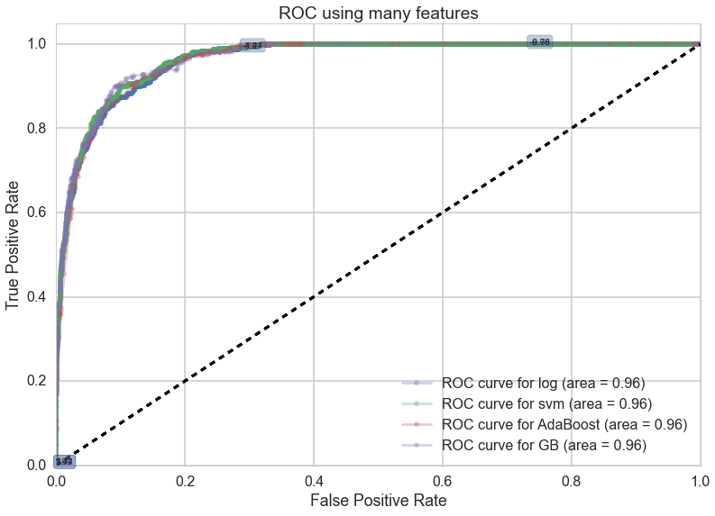

```python
ax1=make_roc("log", clflog2, ytest, Xtest, proba=False,labe=1000)
ax1=make_roc("svm", clfsvm2, ytest, Xtest,proba=False,labe=1000)
ax1=make_roc("AdaBoost", clfAda2, ytest, Xtest, proba=False,labe=1000)
ax1=make_roc("GB", clfGB2, ytest, Xtest,proba=False,labe=1000)
```

Here, we again do not see a significant different between the classifiers as their accuracy on test data is roughly similar.